# Project 2: Public Health & Epidemiology

Merrimack College DSE6630: Healthcare & Life Sciences Analytics

Team Sigma: Alourdes Joseph, June Lemieux, Melissa Nooney

2025-06-25

# 1 Introduction

It is **September of 2020**, right in the middle of the COVID-19 pandemic and during the California statewide shutdown. You have just been hired by the [California Department of Public Health (CDPH) in Vital Records](https://www.cdph.ca.gov/Programs/CHSI/Pages/Vital-Records.aspx) to track non-COVID mortality trends for the past 4 years for which all data have currently been aggregated and de-identified (anonymized). You are told that the purpose is two-fold:

1. **Help the state identify shifts in spatiotemporal mortality trends as a result of the COVID statewide stay-at-home orders.**
2. **Help the state build predictive models for non-COVID causes of mortality to establish a pre-COVID baseline.**

## 1.1 Provided data: California mortalities

You were given properly de-identified data from 2017 - 2020, which contain mortality records for the state of California by gender, leading cause of death, race / ethnicity, and location of death. All data have been taken from the death certificates filed with the state.

**NOTE**: If you are interested in these data, the source is the [California Death Profiles dataset](https://data.chhs.ca.gov/dataset/death-profiles-by-county) maintained by California Health and Human Services.

```r
## Load the provided data files
load("california_mortality_tables.RData")
```

You are provided 6 tables total, which have the following variables.

Table 1. Data dictionary of variables in the California mortality tables.

| **All Tables** |  |
| --- | --- |
| Year | Year of record |
| Month | Month of record |
| County | California county where death was recorded |
| **Annual Mortality Table** |  |
| annualCount | Number of deaths for the sex specified |
| raceEthnicity | Race and/or Ethnicity of the deceased; Latinx is unfortunately treated as a racial category here rather than an ethnic group |
| **Specialized Variables** |  |
| leadingCauseDeath | Leading cause of death per death certificate; See separate table for encoding |
| ageBins | Age groups where the age at death was known |
| ageDeaths | Number of deaths for the age bin specified |
| biologicalSex | Biological sex of decedent |
| sexDeaths | Number of deaths for the sex specified |
| placeDeathOccurred | Location of death, per death certificate |
| placeDeaths | Number of deaths matching specified criteria |
| raceDeaths | Number of deaths matching race / ethnic criteria |
| totalDeaths | Number of deaths per month, year, & county |

Table 2. Underlying cause of death category based on coding using the Tenth Revision of the International Classification of Diseases (ICD) codes

| 3-letter Code | Description | ICD-10 Codes |
| --- | --- | --- |
| HTD | Diseases of the Heart | I00-I09, I11, I13, I20-I51 |
| CAN | Malignant Neoplasms (Cancers) | C00-C97 |
| STK | Cerebrovascular Disease (Stroke) | I60-I69 |
| CLD | Chronic Lower Respiratory Disease (CLRD) | J40-J47 |
| INJ | Unintentional Injuries | V01-X59, Y85-Y86 |
| PNF | Pneumonia and Influenza | J09-J18 |
| DIA | Diabetes Mellitus | E10-E14 |
| ALZ | Alzheimer’s Disease | G30 |
| LIV | Chronic Liver Disease and Cirrhosis | K70, K73-K74 |
| SUI | Intentional Self Harm (Suicide) | U03, X60-X84, Y87.0 |
| HYP | Essential Hypertension and Hypertensive Renal Disease | I10, I12, I15 |
| HOM | Homicide | U01-U02, X85-Y09, Y87.1 |
| NEP | Nephritis, Nephrotic Syndrome and Nephrosis | N00-N07, N17-N19, N25-N27] |
| OTH | All Other Causes of Death | All codes not listed above |

**NOTE**: Make sure to refer to these tables as you go!

# 2 Using Spatial Analysis to Assess Spatiotemporal Trends in Overall Mortality

## 2.1 Background

Unlike your first project, your data engineering team (i.e., **me**) has provided you with most of the data tables in a nice, tidy format that are relatively nice and tidy to begin with - which means you can dig right into the analysis! Remember, any time you have datasets with **spatial information** they are spatial data; these data are organized by California county, so you know you must do a spatial analysis! However, there is also a *temporal* element - you have data from four different years, 2017 to 2020. So, you decide you will make maps to analyze both the spatial (geographic) and temporal (time) trends in the hope it will shed insight into which downstream analysis you should do. Consider this to be part of your **Exploratory Data Analysis**.

As discussed in lecture, one of the key types of spatial data files you might use are called **shapefiles**, which is what you are going to practice loading and working with shapefiles, using this [open source dataset](https://gis.data.ca.gov/datasets/8713ced9b78a4abb97dc130a691a8695/explore) for the state of California. You will have to download these data as they are too large to put onto GitHub.

Begin by downloading the requisite spatial data files. Make sure you put them in their own directory called **California_County_Boundaries** on your Desktop; otherwise, you will need to adjust your path in the file settings below! This is similar to what I had you do in Demo 1, if you’ll recall.

Notice that the directory contains six files, three of them with file extensions you discussed last week in lecture:

- `cnty19_1.cpg`
- `cnty19_1.dbf`
- `cnty19_1.prj`
- `cnty19_1.shp`
- `cnty19_1.shp.xml`
- `cnty19_1.shx`

#### Question 1 [1 point]:

What do each of these six files represent? You will not be able to open them directly on your computer, so you may need to refer back to lecture and do a little digging to figure out the type of data you would expect each of these files to contain.

> AJ- These files are a family of files and work together as a set of components that define both the geometry (shapes and locations) and attributes (names, codes, and metadata) of geographic features for counties in California and must keep them together in the same folder for your GIS or R software to read the shapefile correctly:
> 1. `cnty19_1.cpg` – Specifies the character encoding (e.g., UTF-8) used for reading the text in the .dbf file. It ensures special characters or multilingual text are interpreted correctly.
> 2. `cnty19_1.dbf` – The attribute table stored in dBase format, holding all the non-spatial data—like county names, population values, or other metadata—associated with each shape.
> 3. `cnty19_1.prj`-Stores the projection and coordinate system information used in the spatial data. This is what allows the map to be placed accurately on a globe or another reference system (e.g., WGS84, NAD83, etc.).
> 4. `cnty19_1.shp`-The main file that stores the geometry (points, lines, or polygons) of the spatial features and also the boundary outlines of California’s counties.
> 5. `cnty19_1.shp.xml`-This is a metadata file in XML format. It contains information about the dataset such as who created it, when, and provides descriptions of the fields and is mainly used for documentation purposes.
> 6. `cnty19_1.shx`-This index file allows software to efficiently locate each shape in the .shp file with the records in the .dbf file and also speeds up access to the geometry data.

## 2.2 Your objective

You want to first get a sense for **annual trends** in overall mortality across the state to see what you are working with. Your first objective is to join your overall mortality data to the shapefile to be able to make maps to visualize these trends. You also want to calculate **spatial weights** to allow you to create predictive models of mortality by county.

## 2.3 Making your first map of California

You are going to practice two ways to make maps from shapefiles so that you can see two ways to do it. Also, to give you more for reference, you are roughly following the GIS Basics Chapter of the Epi R Handbook (with your own twist, of course!). This chapter may be helpful for understanding more of the “nuts and bolts” of GIS as well, including definitions and why you might do things certain ways.

**The initial processing steps will include:**

1. Import the shapefile
2. Filter rows to keep only areas of interest
3. Merge with the other data tables to creates maps and analyze trends

### 2.3.1 Read in the shapefile & validate geometries

You will leverage the `read_sf()` function that is part of the `sf` package. As you might have guessed, `sf` refers to **shapefile**. Note that there is an alternative method to read in shapefiles called `st_read`, which is an alias for `read_sf()` with some different default arguments. By default, `read_sf()` is quiet, whereas `read_st()` will print information about the data source by default. Additionally, `read_sf()` returns a tibble rather than a dataframe. So which to choose? It’s your preference, in this case. By default, your code below will use `read_sf()` but you could instead use `read_st()` if you wanted.

```r
getwd()
```

```r
read_sf("/Users/aleej/Desktop/California_County_Boundaries/cnty19_1.shp")
```

```r
cali_sf <- read_sf("C:/Users/Sean/Desktop/California_County_Boundaries/cnty19_1.shp")
# cali_sf <- read_sf("~/Desktop/California_County_Boundaries/cnty19_1.shp")

## Alternatively, you can read in the shapefile using the 'st_read()' function
##cali_st <- st_read("./California_County_Boundaries/cnty19_1.shp")
```

**NOTE** If you get a warning (as opposed to a critical error) is from [GDAL](https://gdal.org/en/stable/), a library of raster and vector geospatial data formats that your `read_sf()` (or `st_read()`) functions are using to transform the polygons for mapping. This warning indicates that some polygon geometries in the shapefile have boundaries (rings) with an inconsistent order of coordinates (“invalid winding order”). GIS tools assume that it will read from the right-hand, and the warning is letting you know that it is autocorrecting it. However, you could still have issues and it isn’t ideal.

*Just as you did in Demo 2, you can fix this by validating the polygon boundaries:*

```r
## Disable Google S2 engine
sf_use_s2(FALSE)
## Validate the geometry boundaries/edges
cali_sf <- st_make_valid(cali_sf)
```

*Now, let’s do a quick check of the map of California counties to make sure all the layers look okay:*

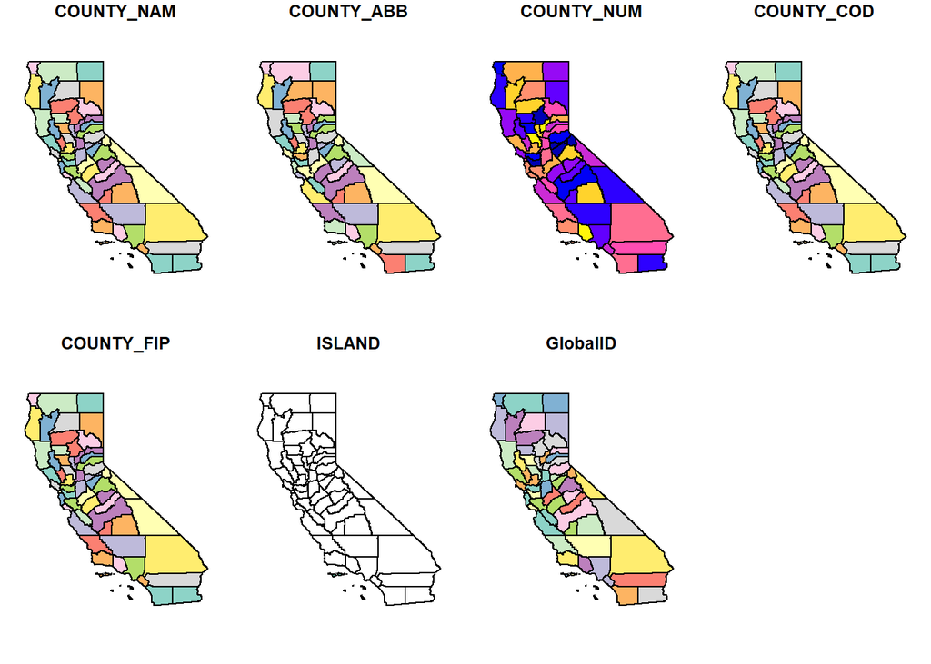

```r
plot(cali_sf)
```

*And let’s check the validity of the boundaries:*

```r
st_is_valid(cali_sf)
```

```
##  [1] TRUE TRUE TRUE TRUE TRUE TRUE TRUE TRUE TRUE TRUE TRUE TRUE TRUE TRUE TRUE
## [16] TRUE TRUE TRUE TRUE TRUE TRUE TRUE TRUE TRUE TRUE TRUE TRUE TRUE TRUE TRUE
## [31] TRUE TRUE TRUE TRUE TRUE TRUE TRUE TRUE TRUE TRUE TRUE TRUE TRUE TRUE TRUE
## [46] TRUE TRUE TRUE TRUE TRUE TRUE TRUE TRUE TRUE TRUE TRUE TRUE TRUE TRUE TRUE
## [61] TRUE TRUE TRUE TRUE TRUE TRUE TRUE TRUE TRUE
```

#### Question 2 [1 point]:

Why did `TRUE` print 69 times? What are the “69 features” in the geometry?

**Hint 1**: Are all of them counties? If not, what are they? Try running `print(calif_sf$COUNTY_NAME`. What do you see?

**Hint 2**: There are islands in California. What happens to islands in terms of `COUNTY_NAM`?

> AJ-TRUE printed 69 times because the shapefile contains 69 geographic features, each representing a polygon (or multiple polygon) that maps a spatial area. Since California has only 58 counties, it is likely that some counties are represented by multiple polygons especially those with island or non-contiguous regions, such as parts of San Francisco, Marin, or Los Angeles Counties.

*Next, let’s take a look at the geometry of the shapefile that you loaded.*

```r
cali_sf$geometry
```

```
## Geometry set for 69 features
## Geometry type: GEOMETRY
## Dimension:     XY
## Bounding box:  xmin: -13849230 ymin: 3833650 xmax: -12704980 ymax: 5162403
## Projected CRS: WGS 84 / Pseudo-Mercator
## First 5 geometries:
```

Notice that, just like Demo 2, you only have the **polygon** geometry in your shapefile. If you were to investigate further, you would find that currently there are no other geometries (e.g., lines or points) in this shapefile. You could add them and export the shapefile, if you ever needed to do so, like to share with someone else. For example, if you wanted to add points for the county seats of each county, you could add them based on longitude and latitude; similarly, you could add just points for major California cities, which I will demonstrate below.

#### Question 3A [0.5 points]:

What is the bounding box that comes with your shapefile and what does it tell us? **What would you do to the bounding box if you wanted to zoom in or out on a geographic feature?**

> AJ- xmin: -13849230  
> ymin: 3833650  
> xmax: -12704980  
> ymax: 5162403 The bounding box defines the spatial extent of the California shapefile in the WGS 84 / Pseudo-Mercator projection and adjusting it lets you zoom in or out of your map. It tells us the rectangular boundary that contains all 69 geometries which includes counties and islands and any spatial feature outside this box will not be displayed.

#### Question 3B [0.5 points]:

What is the projection? What does it tell you and why does projection matter? **What will change if you change the projection?**

> AJ-The file uses the WGS 84 / Pseudo-Mercator projection, which is ideal for web mapping due to its simplicity and 2D structure, though it’s known to distort area and distance, especially at larger scales. Projection defines how spatial data is transformed from the Earth’s curved surface to a flat map. It determines the coordinate system whether the measurements are in degrees, meters and feet etc.and affects how shape, area, and distance are represented. Changing the projection alters the spatial reference system and can impact how your data looks and behaves: Coordinate values will differ (e.g., from meters to degrees), and map features may shift slightly depending on the distortion characteristics of the new projection. Therefore, it’s important to choose a projection suited to your region and analysis type more and also that preserves area and distance relationships more accurately for regional analysis.

### 2.3.2 Create a basic map of California

In Demo 2, I showed you how to plot shapefiles using `ggplot2`’s `geom_sf()` function, and even though there are advanced mapping functions in R you could use you will stick with that for consistency, convenience, and speed.

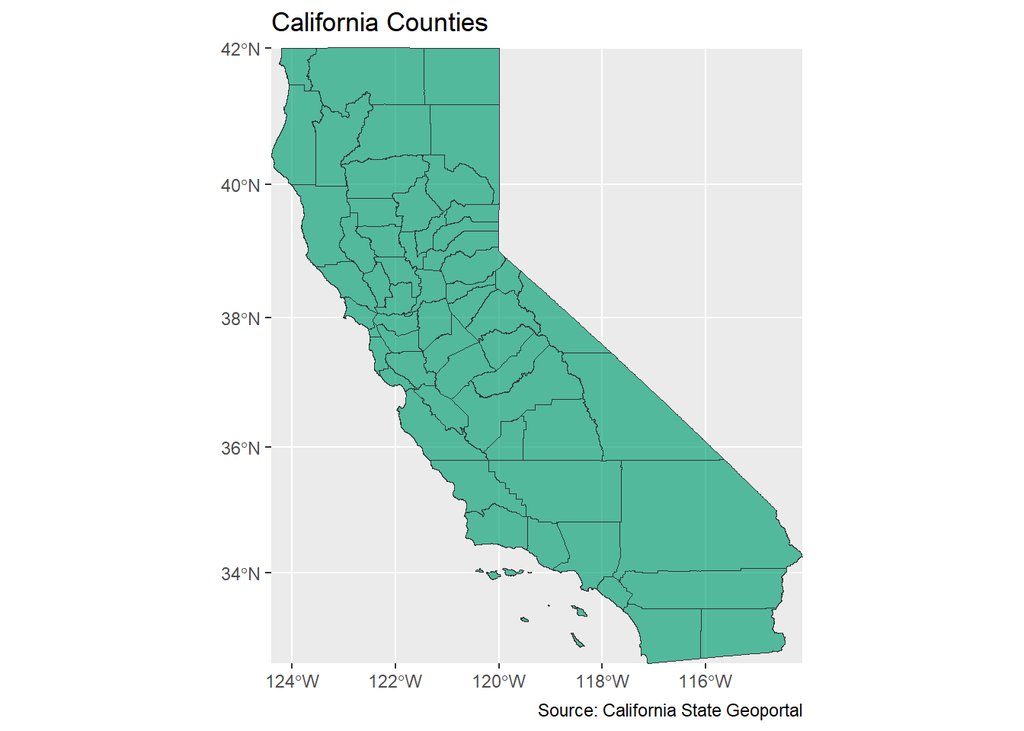

```r
## Initiate the plot and tell it the dataset
ggplot(data = cali_sf) +
  ## Give it specific fill and border colors
  geom_sf(fill = skittles[6],
          color = "gray20",
          linewidth = 0.25,
          alpha = 0.65) +

  ## Set map projection explicitly
  coord_sf(expand = FALSE) +   ## <- keeps map tight to its bounding box

  ## Uncomment to make a completely blank map background
  # theme(
  #   panel.grid = element_blank(),
  #   panel.background = element_rect(fill = "white"),
  #   plot.background = element_rect(fill = "white"),
  #   axis.text = element_blank(),
  #   axis.ticks = element_blank(),
  #   axis.title = element_blank(),
  # ) +

  ## Give it a title and footnote/caption
  labs(title = "California Counties",
       caption = "Source: California State Geoportal")
```

### 2.3.3 Zooming in on the map

Now, what if you only wanted to visualize a few counties? Let’s look at the three northernmost counties that border Oregon. The three northernmost California counties that border Oregon are:

- Del Norte
- Siskiyou
- Modoc

Notice that the county names are accessible through `cali_sf$COUNTY_NAM`. Thus, you can just use the `filter()` function from `dplyr` to be able to grab the three northernmost counties you want by name, which I have started for you.

#### Question 4 [1 point]:

Finish the code below to create a map of the northernmost 3 counties in California. You can copy and paste, with minor modifications, the code for the entire state map to do this. **NOTE** that you are storing your map into `map1`. This is because I will show you how to add labels in the next section! Don’t forget to update your plot title for full credit!

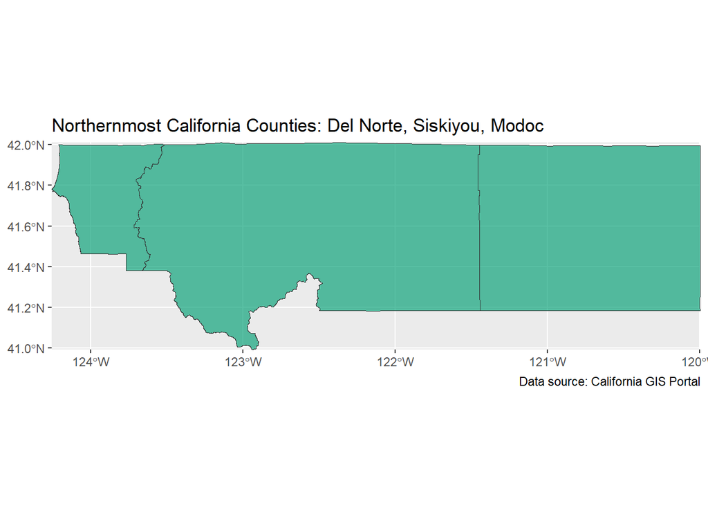

```r
# ## Start from the California spatial tibble - Uncomment to run
# map1 <- cali_sf %>%
#   ## Filter to just the 3 counties that border Oregon - Uncomment to run
#   filter(COUNTY_NAM == "Del Norte" | COUNTY_NAM == "Siskiyou" | COUNTY_NAM == "Modoc") %>%

library(dplyr)
library(ggplot2)

map1 <- cali_sf %>%
  filter(COUNTY_NAM %in% c("Del Norte", "Siskiyou", "Modoc")) %>%
  ggplot() +
    geom_sf(fill = skittles[6],
            color = "gray20",
            linewidth = 0.25,
            alpha = 0.65) +
    coord_sf(expand = FALSE) +
    labs(
      title = "Northernmost California Counties: Del Norte, Siskiyou, Modoc",
      caption = "Data source: California GIS Portal"
    )

# To display:
print(map1)
```

*Now let’s add labels!* This code will not run unless you have made `map1` correctly!

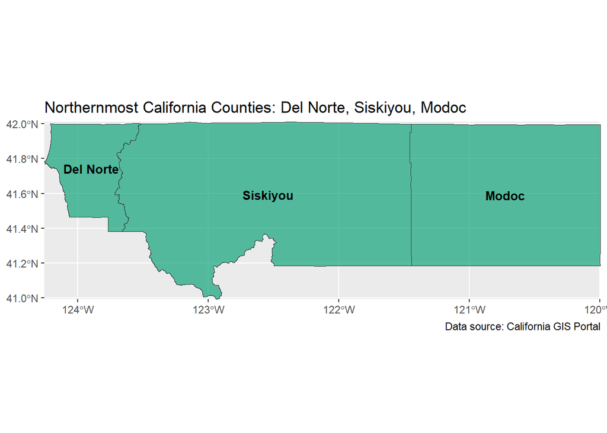

```r
### UNCOMMENT THIS CODE TO RUN:

# ## Calculate the county centers:
 county_centroids <- st_centroid(cali_sf) %>%
# ## Filter for just the northern centroids
   filter(COUNTY_NAM == "Del Norte" | COUNTY_NAM == "Siskiyou" | COUNTY_NAM == "Modoc")
#
# ## Now, add the labels to the map:
map1 + geom_sf_text(data = county_centroids,
                    aes(label = COUNTY_NAM),
                    size = 3.5, fontface = "bold") +
#   ## fix the x and y axis labels to make a beautiful map!
  theme(axis.title = element_blank())
```

## 2.3.4 Creating points for major cities in California

- Sacramento (the capital)
- Los Angeles
- San Diego
- San Francisco

But, to do this, it takes a little sorcery. You have to create a second **layer** for the points you want to overlay. So, you will put the longitude and latitude for each city, with the city’s name and an identifier as to whether it’s the capital or not, into its own dataframe. You will then convert it to a shapefile object.

```r
## Create a cities data frame with coordinates
cities <- data.frame(
  city = c("Sacramento", "San Diego", "Los Angeles", "San Francisco"),
  lon = c(-121.4944, -117.1611, -118.2437, -122.4194),
  lat = c(38.5816, 32.7157, 34.0522, 37.7749),
  cityType = c("capital", "major", "major", "major")
)

## Convert to shapefile object with the same projection as what you had
cities_sf <- st_as_sf(cities, coords = c("lon", "lat"), crs = 4326)
```

*Now, you can plot the map by overlaying the city points, with differing colors for each city and a different shape and size marker for the capital, Sacramento:*

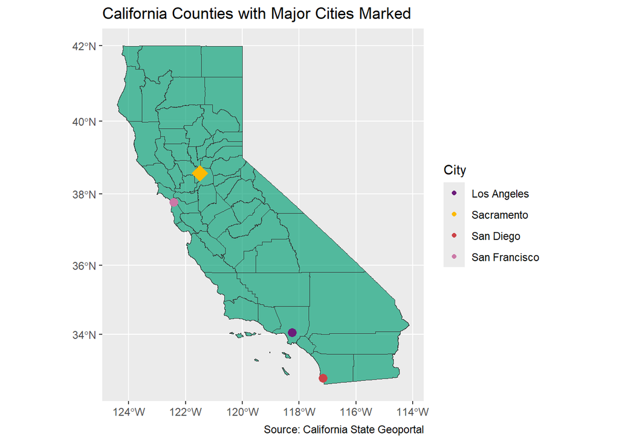

#### Question 5 [1 point]:

Your stakeholders point out that you have forgotten San Jose, one of the most populated cities in California! They ask you to go back to the map and add it on.

**Hint 1**: The coordinates of San Jose are 37.3387° N, 121.8853° W **Hint 2**: Don’t forget to add a `cityType` for San Jose! **Hint 3**: Don’t forget to add a skittles color for San Jose in `scale_color_manual`!

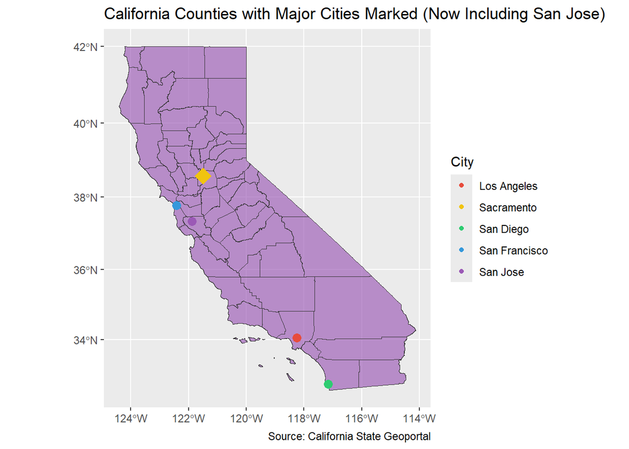

```r
## Add San Jose to the cities data frame
cities <- data.frame(
  city = c("Sacramento", "San Diego", "Los Angeles", "San Francisco", "San Jose"),
  lon = c(-121.4944, -117.1611, -118.2437, -122.4194, -121.8853),
  lat = c(38.5816, 32.7157, 34.0522, 37.7749, 37.3387),
  cityType = c("capital", "major", "major", "major", "major")
)

## Convert to spatial object
cities_sf <- st_as_sf(cities, coords = c("lon", "lat"), crs = 4326) %>%
  st_transform(crs = st_crs(cali_sf))

## Update color palette to include a color for San Jose
skittles <- c("#E74C3C", "#F1C40F", "#2ECC71", "#3498DB", "#9B59B6")

## Plot the map with updated cities
ggplot(data = cali_sf) +
  geom_sf(fill = skittles[5], color = "gray20", linewidth = 0.25, alpha = 0.65) +
  coord_sf(expand = FALSE) +
  geom_sf(data = cities_sf,
          aes(color = city, shape = cityType, size = cityType)) +
  scale_shape_manual(values = c(capital = 18, major = 16), guide = "none") +
  scale_size_manual(values = c(capital = 6, major = 3), guide = "none") +
  scale_color_manual(values = skittles, name = "City") +
  labs(title = "California Counties with Major Cities Marked (Now Including San Jose)",
       caption = "Source: California State Geoportal")
```

## 2.4 Joining shapefiles with a tibble or dataframe

As mentioned above, the `sf_read()` function from the `sf` package loads your shapefile as a `tibble`, which makes life much easier for you when dealing with shapefiles. It also means you can easily join your shapefiles with other tibbles / dataframes, like the ones we’ve imported of mortality data. Let’s briefly breakdown what your process to do this is going to look like:

**Our Process:**

1. Rename the **County** column so it matches the shapefile
2. Summarize the data by **Year** so you can visualize the annual trends
3. Join the two tibbles by `COUNTY_NAME`
4. Make sure to turn the joined tibble **back into a shapefile** using the `st_as_sf()` function, otherwise it will fail. The join will convert it into a structure that is no longer a shapefile, so you have to back-convert it to a shapefile!
5. You are going to remove the islands, not because you dislike islands but because they get labeled separately and make your map look cluttered. Further, the few people who reside on the islands of California will still be included in their onshore county, so you are not ignoring anyone. *Feel free to experiment removing that filter to see what I mean!*

#### Question 6 [1 point]:

Annotate the following code chunk with comments to make sure you understand what you are doing here. **HINT**: refer back to the earlier tables with the data descriptions to help you understand the data better!

```r
## Total monthly mortality data by county and year
mortality_sf <- totalDeaths %>%
  ## Rename County column  to match shapefile’s COUNTY_NAM field
  rename(COUNTY_NAM = County) %>%
  ## Group by county and time to  get total deaths per county per month/year
  group_by(COUNTY_NAM, Year, Month) %>%
  ## Summarize total deaths counts within each group, removing any NA values
  summarise(totalDeaths = sum(totalDeaths, na.rm = TRUE)) %>%
  ## Perform a full join with the shapefile using COUNTY_NAM as the key
  ## relationship = "many-to-many"' ensures that multiple geometries per county are preserved in the merge
  full_join(cali_sf, by = "COUNTY_NAM", relationship = "many-to-many") %>%
  ## Convert the joined table back into an sf object so it retains spatial features
  st_as_sf() %>%
  ## Filter out separate island geometries to reduce clutter in maps,keep only rows where ISLAND is NA
  filter(is.na(ISLAND))
```

#### Question 7A [0.5 points]:

What does `st_join()` do? Could you have executed the join with `st_join()` instead of `full_join()` here? Why or why not?

> AJ-`st_join()` performs a spatial join by merging attributes from one sf object to another based on a spatial predicate (e.g., intersection, contains). It is not designed for simple attribute-based joins. In this case, since we are matching on the county name column rather than on spatial relationships, `full_join()` or another dplyr join is appropriate. Since your mortality data is a non-spatial tibble and being matched based on a shared attribute (COUNTY_NAM), a dplyr join is what is needed. Spatial joins like `st_join()` only come into play when both data layers have geometries and their physical relationships (e.g., containment, distance, intersection) can be rely on.

#### Question 7B [0.5 points]:

This question has three subparts.

1. How many features are there in `mortality_sf`?

```r
## Count the number of features in the spatial object
nrow(mortality_sf)
```

```
## [1] 2552
```

2. Why is it so many more than in `cali_sf`? > AJ-`Mortality_sf` has many repeated records for each county across time since it’s a spatiotemporal table: it includes one row per county for each month across each year in the mortality data (e.g., 58 counties × 12 months × 4 years = up to 2,784 records). In contrast, `cali_sf` has just one row per spatial feature (county polygon or island part). This time dimension multiplies the number of rows.`cali_sf` contains 69 geometry features, reflecting California’s 58 counties plus extra polygons for islands or non-contiguous areas.The time dimension in mortality_sf significantly multiplies the number of rows.
3. How many counties are there now in `COUNTY_NAM`? (Hint: Use `unique()` or `n_distinct()` to help you get the true number!) Why is it different from the number you saw in Question 2?

```r
 n_distinct(mortality_sf$COUNTY_NAM)
```

```
## [1] 58
```

> AJ-In Question 2, 69 features were identified because those were geometry parts (counties plus separate island polygons), whereas here the count is unique to county names.

## 2.5 Visualizing annual trends in overall mortality

You are asked to make four maps, one for each year, that shows how annual overall mortality trends to identify any changes as a result of either the COVID-19 pandemic or the stay-at-home orders. Notice that you first use a `group_by()` and a `summarize()` to tally the total deaths per county per year - but **unlike your previous chloropeths**, you are applying a purposeful set of cuts every $5 \times 10^n$ deaths. Why? This is to allow you to see [order of magnitude](https://en.wikipedia.org/wiki/Order_of_magnitude) changes in the total deaths by California counties for each of the four years.

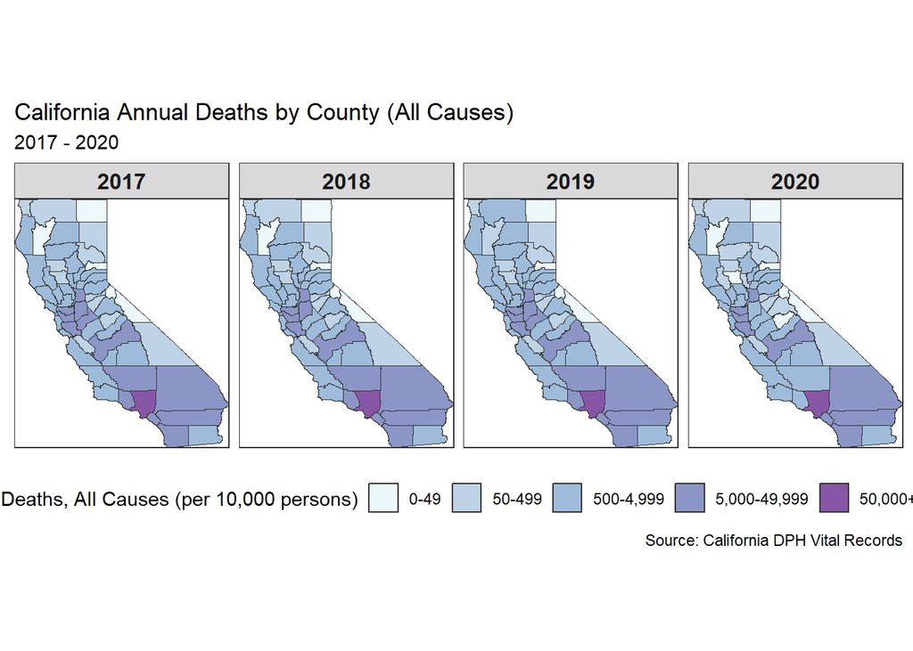

```r
## Start from the mortality spatial tibble
mortalitySummary <- mortality_sf %>%
  ## Group by and then summarize to total the deaths by County and Year
  group_by(COUNTY_NAM, Year) %>%
  summarise(totalDeaths = sum(totalDeaths, na.rm = TRUE)) %>%
  mutate(deathLabels = cut(totalDeaths,
                          breaks = c(0, 50, 500, 5000, 50000, Inf),
                          labels = c("0-49", "50-499", "500-4,999",
                                    "5,000-49,999", "50,000+"),
                          ordered_result = TRUE, right = F))
## Initialize the plot
ggplot(mortalitySummary) +
  ## Chloropeth: draw the polygons of the counties and color by total deaths
  geom_sf(aes(fill = deathLabels), color = "gray20", size = 0.2) +
  ## Apply manual fill scale for total deaths
  scale_fill_manual(
    name = "Deaths, All Causes (per 10,000 persons)",
    values = c4a(palette="BuPu", n=6),
    drop = FALSE
  ) +
  ## Set map projection explicitly
  coord_sf(expand = FALSE) +   ## <- keeps map tight to its bounding box
  theme_bw() +
  ## Make a completely blank map background this time
  theme(
    panel.grid = element_blank(),
    panel.background = element_rect(fill = "white"),
    plot.background = element_rect(fill = "white"),
    axis.text = element_blank(),
    axis.ticks = element_blank(),
    axis.title = element_blank(),
    strip.text = element_text(size = 12, face = "bold"),
    legend.position = "bottom"
  ) +
  labs(
    title = "California Annual Deaths by County (All Causes)",
    subtitle = "2017 - 2020",
    caption = "Source: California DPH Vital Records"
  ) +
  ## Use facet_wrap to make one map per year
  facet_wrap(~ Year, ncol = 4)
```

### 2.5.1 Uh oh, can you spot the problem?

#### Question 8 [1 point]:

Is there any pattern that is a cause for concern in your interpretation of **total deaths**?

**Hint 1**: The county with the highest number of deaths (darkest purple) is **Los Angeles county**. What is special about LA county? **Hint 2**: Do you see other similar darker colors in counties around cities?

> AJ-The pattern of highest total deaths in Los Angeles County and similarly high totals in other populous urban counties like San Diego, San Francisco, and Sacramento reflects population size rather than necessarily higher mortality risk. The raw totals are driven by how many people live in a large county metro areas and will always show darker colors. There’s a potentially misleading pattern when interpreting total deaths without adjusting for population size.Total deaths is not meant as indicating “worse” outcomes without adjusting for population or age structure. To make the maps more informative, compute per-capita (or age-standardized) mortality rates so to compare risk rather than sheer counts (e.g., deaths per 10,000 people) to show true spatial disparities and not just population effects.

## 2.6 Accessing the 2020 US Census API

Hopefully, you have figured out that you need population data to add to your dataframes. In Demo 2, I gave you Census data - but this time, I want to teach you how to more efficiently and iteratively access data through an **API** (Application Programming Interface), which acts as a bridge between two software programs to exchange data. As data scientists, learning to use and love APIs will serve you well! *Thus, for the Census data this time you are going to access the Census Bureau’s API endpoint.*

If you have not yet worked with an API, never fear! That’s why we’re doing it here. Here, the Census API will allow you to access their database and download their data in JSON (Java Script Object Notation) format, which is format that **flattens** databases into text. By connecting to the API endpoint for the Census Bureau, you will be able to download instantaneously only the data you want, which in your case will be population sizes and some basic demographics about the breakdown of population by sex and by individuals over the age of 65 years.

Because the US Census API uses JSON formatted files, you will be using the `jsonlite` package to convert the JSON files to a dataframe. But first, you need to gain access to the API!

### 2.6.1 Getting your first Census API Key (unless you already have one)

In order to access the Census API, you will need your own Census API key. I could give you mine, but it’s generally not good practice to share API keys unless you trust the person. Why? (1) If someone misuses your API key, you could get banned from accessing the API. (2) Especially for government or non-profit agencies, it can be a good idea to have your own so that they can keep track of how many users they have. Not all API access is free, but for government, non-profit, or institutionally held data, access is free although you may have different hoops to jump through for access depending on how secure they want to keep the data. (e.g., to protect survey respondents).

#### Question 9 [1 point]:

You will sign up for your API census key [here](https://api.census.gov/data/key_signup.html). You should be able to obtain your key very quickly, but if you run into trouble then I will give you the data I have downloaded through **my** API key so that you can still keep going with the project.

Once your have your key, fill it into this code chunk here:

```r
## Set your API key (put it between the quotation marks):
key <- "aabaee4339a0e6eaa48e4435f58e46f49687ca2a"
```

### 2.6.2 Downloading data tables from the 2020 Census API

You are going to use the 2020 Census since that is the last year of data you have for the mortality dataset. The U.S. Census maintains numerous tables you can use for data. You will be using the **Decennial Census: Demographic Profile**. You can find the variable explanations for this table of the 2020 Census data here. Below is a custom function I have written that will allow you to extract any of the variables you want from this table as long as you follow the usage.

**HOW TO GET DATA FROM AN API: THE `url`**

The important thing to understand about APIs is that they are based on the `url` to the API endpoint. For example,

`https://api.census.gov/data/2020/dec/dp?get=NAME,DP1_0001C,DP1_0025C&for=county:*&in=state:06&key=YOUR_API_KEY`

is a `url` that you can break down into its constituent parts like this:

| Component | Description |
| --- | --- |
| `https://api.census.gov/data` | Base API endpoint |
| `/2020/dec/dp` | Specific dataset path (2020 Decennial Census, Data Profile) |
| `?get=NAME,DP1_0001C,DP1_0025C` | Variables to retrieve (`NAME` and 2 demographic variables, `DP1_0001C` and `DP1_0025C`) |
| `&for=county:*` | Requesting data for **all counties** |
| `&in=state:06` | Restricting to **California** (FIPS code 06) |
| `&key=YOUR_API_KEY` | Your **personal API key** (required for access) |

You can practice modifying this `url` by adding your personal key to the end. If you do, what you’ll see is something is this if you copy and paste the **completed `url`** into your browser:

[figure not shown]

This is the Census data for the two variables chosen in `JSON` format! You can then convert these into a dataframe using the `fromJSON()` function from the `jsonlite` library, although this is not the only `JSON` handling package that exists in R. Similar packages exist in Python.

**HOW THE FUNCTION WORKS**

The custom function, `getPopSizes()`, pulls population data from the U.S. Census API for all counties in California, specifically demographic details like total population, gender counts, and age 65+ breakdowns from the 2020 Decennial Census.

*Before you run the function, you must set the stage:*

- `state = "06"`
  - Sets the state FIPS code for California (FIPS 06 = CA)
  - If you wanted all states, you’d use “*”
- `vars`
  - A vector of Census variable codes for population totals, age, and sex breakdowns
  - For example, `DP1_0001C` is total population
- `header`
  - A human-readable list of column names that will replace the technical variable codes in `vars`

#### Question 10A [0.5 points]:

Using a search engine or the [Census table explorer](https://data.census.gov), whichever you find easier to use, look for the differences between table variables `DP1_0048C` and `DP1_0048P`. What different information do these two variables hold?

> AJ-`DP1_0048C` gives you the raw number, while `DP1_0048P` gives you the proportion relative to the total population but both refer to the same demographic group (male population aged 65 years and over). This distinction is important depending on whether analyzing absolute population size or demographic composition.

*Digging into the Function*

The function `getPopSizes()` takes in the following information as **arguments** to be able to run correctly:

- `key`: your Census API key
- `vars`: variable codes
- `header`: column names you want

Then, inside the function, it is doing several key tasks:

1. Builds the `url` for the API request
- Adds variables to `get=...`
- Limits to counties in California via `for=county:*&in=state:06`
- Appends the API key at the end of the `url`
2. Requests the data from the Census API using `fromJSON(url)` and converts it to a data frame
3. Cleans the data for you
- Removes the first row (which contains column names from the API)
- Renames columns using `header`
- Converts character columns back into numbers (`mutate_at`)
4. Returns a cleaned data frame of all the census variables requested, complete with human-readable headers!
- This dataframe is now ready to be joined with your mortality shapefile!

**Function call** This line runs the function using your API key and saves the result to a variable called `census`: `census <- getPopSizes(key, vars, header)`

**NOTE** Make sure to change `include=FALSE` to `TRUE` in the first line (the `{r}` setup line) the chunk or you will get an error upon knitting.

```r
## Set the state want you in double-digit FIPS; if you want all states, use *
state = "06" ## California

## Set a vector of variables you want; no need to include NAME,
## it's already written into the function
vars <- c("DP1_0001C", "DP1_0025C", "DP1_0049C", "DP1_0024C",
          "DP1_0024P", "DP1_0048C", "DP1_0048P", "DP1_0072C",
          "DP1_0072P")

## Set my header
header <- c("totalN", "malesN", "femalesN", "over65", "over65perc",
            "males65plus", "males65plusPerc", "females65plus",
            "females65plusPerc")

getPopSizes <- function(key, vars, header) {
  ## Building your url

  ## initialize "get" variable
  get <- "NAME"
  ## For each of the variable, add in the codes to the "get" variable so you can
  ## add that into the API address
  for(i in 1:length(vars)){
    get <- paste(get, vars[i], sep="&")
  }
  ## Add in more of the necessary pieces into the API address
  for.statemt <- paste0("&for=county:*&in=state:", state)
  base.url <- "https://api.census.gov/data/2020/dec/dp"
  ## The finished URL that you will use to get the JSON file
  url <- paste0(base.url, "?get=", get, for.statemt, "&key=", key)

  ## Use fromJSON() to get the data table and turn into a data frame
  census <- data.frame(fromJSON(url))
  census <- census[-1, ]  ## first row needs to be dropped

  ## Rename the columns with what you want
  names(census) <- c("NAME", header, "STATE", "COUNTY")

  ## Fix the fact that everything numeric was turned into character
  census <- census %>%
      mutate_at(header, as.numeric)

  ## Done!
  return(census)
}

## Call the function
census <- getPopSizes(key, vars, header)
## Remove the extra characters from the name of the county
census <- census %>%
  mutate(NAME = gsub(" County, California", "", NAME)) %>%
  rename(County = NAME)
```

**Did you notice how quickly it accessed the information?** That is one of the strengths of APIs. You also get to customize the tables to only grab what you want and you can imagine how you might iterative over multiple years or other structures using a function similar to what I coded for you above. APIs are wonderful to become familiar with as a data scientist; I highly recommend practicing more with APIs as you move toward the job market as it is a highly sought after skill! I also strongly recommend the R package [`tidycensus`](https://walker-data.com/tidycensus/); I did not choose to use that here so you would have **generic code** you could use for many API endpoints going forward in your career! Additionally, `tidycensus` is restrictive since it only access some tables of the Census (notably the American Community Survey or ACS), but you were using a different table here.

#### Question 10B [0.5 points]:

Use code or some other method to explore the resulting dataframe, `census`. Explain what this dataframe contains.

> AJ-The census dataframe contains county level demographic data for all California counties which has been sourced from the 2020 Decennial Census, specifically the Demographic Profile (DP) tables. It includes nine numerical variables that describe population counts and percentages. This dataset provides a valuable demographic snapshot that is ideal for normalizing mortality data and exploring age-specific public health trends..

#### Question 11 [1 point]:

Now that you know more generally how this function works and have seen it in action, in your own words, explain how you could adapt this approach (or even this function!) to work with a different API (not the Census). I am not asking you to code, but I am asking you to think through:

1. What key pieces of the function would you need to change?
2. What general steps stay the same regardless of the API?
- **Hint 1**: Think about how the `url` is built and what makes it specific to the Census API.
- **Hint 2**: Think about how the data is retrieved (e.g., using `fromJSON()`) and cleaned afterward.
- **Hint 3**: For simplicity, assume that the data retrieved are in `JSON` format, since that is the most commonly used format.

> AJ- Overall, the structure of the function from building the URL and sending the request, to parsing the JSON response and cleaning the results remains consistent across APIs, regardless of the domain (e.g., Census, weather, finance). However, the specific details such as the base URL, query parameters, and response format—must be adapted to align with the design of the new API.

### 2.6.3 Joining the census with the spatial data and updating the maps

#### Question 12 [3 points]:

Now, it’s your turn to do some work! Your task is to join the census data to the shapefile of overall mortality we’ve already made. You want a tibble that contains all of the data from the census dataframe and all of the data from `mortality_sf`. I called mine `mortality_sf2`, so you will want to call yours the same unless you plan to change the variable name everywhere else downstream.

- **Hint 1**: The easiest way is to use the FIPS data to join.
- **Hint 2**: Don’t worry about calculating % mortality yet. I will help you with that below.
- **Hint 3**: If you’re having problems, check your data types!

```r
## Standardize the join column
census <- census %>% mutate(COUNTY_NAM = as.character(COUNTY))
mortality_sf <- mortality_sf %>% mutate(COUNTY_NAM = as.character(COUNTY_NAM))

## Join the datasets by FIPS code
mortality_sf2 <- mortality_sf %>%
  left_join(census, by = "COUNTY_NAM")
```

**Note**: If you’re unable to do this for any reason, you can pick back up here. You will need to download the data from [Google Drive](https://drive.google.com/file/d/15MT127zoySDS7kOfr9uhLwPSIWBCok1W/view?usp=sharing), as the shapefile is too large for GitHub yet again. I have placed mine on my Desktop, but you can put it anywhere you like and update the directory path. Just make sure not to put it in your GitHub repo!

```r
## Comment me out or change EVAL=FALSE to run your own versions!
load("C:/Users/Sean/Desktop/mortality_sf2.Rdata")
#load("C:/Users/mnoon/OneDrive/Desktop/mortality_sf2.Rdata")
load("census.Rdata")
```

## 2.7 Mapping population-adjusted mortality

Now, at this point, you were so excited to have these data that you decide to next calculate the annual population-adjusted % mortality per county per year so that you could recreate the map you tried to make above. **Notice** that, this time, I set the color scale for the chloropeth to equal the **five number summary** from `fivenum()` so that you could more easily see the median versus the quartiles.

**NOTE**: If you get errors here, it is because your `mortality_sf2` object is not quite right!

```r
##### Calculate the annual percent mortality
mortalitySummary <- mortality_sf2 %>%
  ## Group by County as well as Year
  group_by(COUNTY_NAM, Year) %>%
  ## Summarize by calculating an annual percent mortality
  ## Note that I have to divide by the mean of the N from the Census
  ## or I'd get an error
  summarize(annualPercMortality = 100*(sum(totalDeaths,
                                           na.rm = TRUE)/mean(totalN))) %>%
  ## Ungroup - necessary to remove the grouping for future use
  ungroup()

#### Find the five number summary
summ <- fivenum(mortalitySummary$annualPercMortality)
paste0("The five-number summary of annual % total mortality is: ")
```

```
## [1] "The five-number summary of annual % total mortality is: "
```

```r
paste(c("Min", "Lower Quartile", "Median", "Upper Quartile", "Max"),
      round(summ, 3))
```

```
## [1] "Min 0"                "Lower Quartile 0.494" "Median 0.648"
## [4] "Upper Quartile 0.778" "Max 1.392"
```

```r
##### Now add on the cuts and labels for mapping:
mortalitySummary <- mortalitySummary %>%
  mutate(deathLabels = cut(annualPercMortality,
                          breaks = c(summ, Inf),
                          labels = c("0-0.493", "0.494-0.647", "0.648-0.777",
                                    "0.778-1.391", "1.392+"),
                          ordered_result = TRUE, right = F))
```

Your population-adjusted map now shows the **percent mortality** in the population rather than total numbers of deaths. In other words, **per capita**, what percentage of total deaths were there each year?

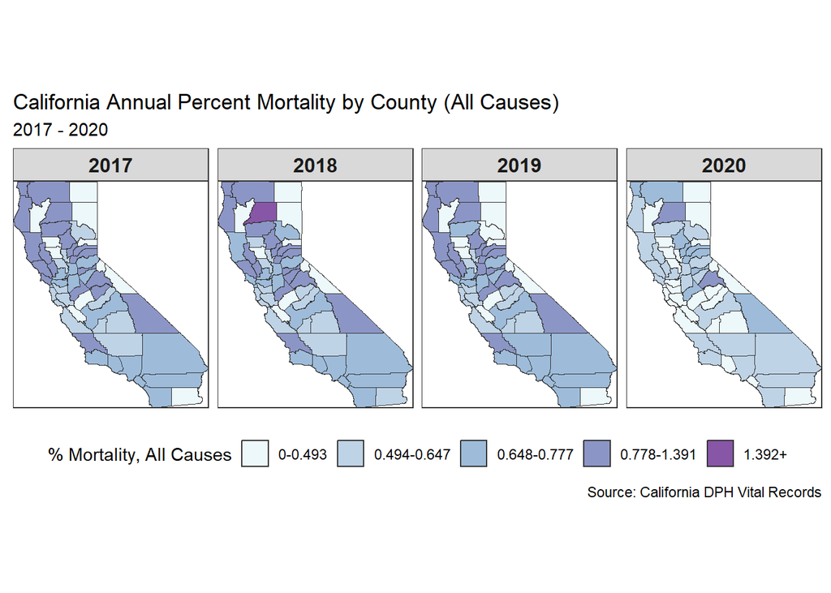

#### Question 13 [1 points]:

What patterns do you observe now, if any? Do you think this is a true pattern? Aren’t you being told that deaths are going **up** due to COVID-19??

> MN: One pattern I see from the map is that as we get to 2020, the previous years maps have darker coloring overall, indicating to me that 2017-2019 have higher all-cause Annual Percent Mortality. One would want to believe thought that 2020 should be higher overall with the increased deaths due to COVID.

## 2.8 The data for 2020 isn’t complete…

Ohhhh… that’s right. The pattern observed is simply a by-product of an incomplete record from 2020, isn’t it?! You only have 8 months’ of observations. You realize at this point you were so excited to jump into map-making that you missed something in how you were doing your calculations and/or planning your maps.

You decide that you had better take a look at both annual and monthly trends in the total numbers of deaths to see if that sheds some light on things:

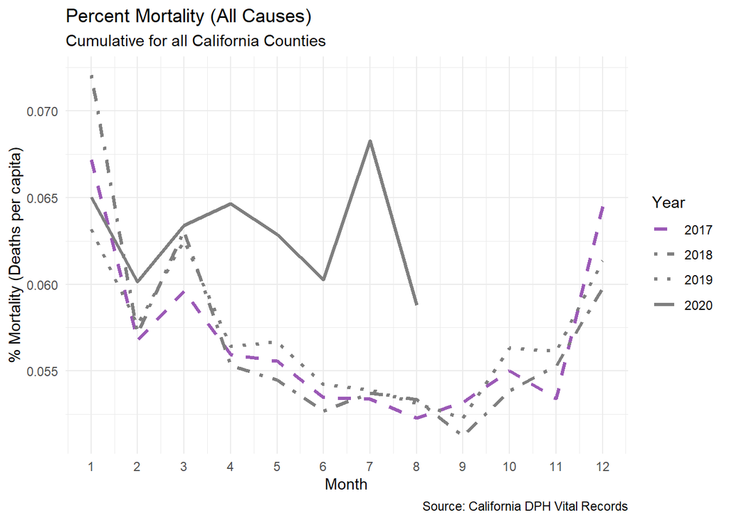

```r
#### Start from the totalDeaths dataframe for simplicity
totalDeaths %>%
  ## Join with census by County
  full_join(census, by = "County") %>%
  ## Group by Year and then Month to aggregate the counties
  group_by(Year, Month) %>%
  ## Calculate the percent mortality - it is a percen because multiply by 100
  summarise(percMortality = sum(totalDeaths, na.rm = TRUE) /
              sum(totalN, na.rm = TRUE)*100) %>%
## Make the plot of % mortality by month and year
ggplot(aes(x = Month, y = percMortality,
           color = as.factor(Year), linetype = as.factor(Year))) +
  ## Line plot
  geom_line(alpha = 1, size = 1.1) +
  scale_x_continuous(n.breaks = 10) +
  ## Make separate colored, patterned lines for each of 4 years:
  scale_color_manual(values = skittles[c(5,9:11)]) +
  scale_linetype_manual(values=c("dashed", "dotdash", "dotted", "solid")) +
  ## Add titles and axis, legend labels
  labs(title = "Percent Mortality (All Causes)",
       y = "% Mortality (Deaths per capita)",
       subtitle = "Cumulative for all California Counties",
       caption = "Source: California DPH Vital Records",
       color = "Year",
       linetype = "Year") +
  theme_minimal()
```

#### Question 14 [1 point]:

Why did this happen and how could you fix it? (**There is more than one correct answer possible.**) Could you have made your maps the way you did in Section 2.7 and had them be accurate if we’d had a full 12 months’ of data for each year?

> MN: I think that if we had a full 12 months of data, then that would increase accuracy because you are looking at the full comparison of other years plus a full year of 2020. Perhaps comparing monthly rates would provide a more complete picture.

## 3.1 Fixing the map’s accuracy for 2020.

Although there are several ways you could tackle this, what I show you below is how to take an average of monthly % mortality so that it no longer matters whether you have 8 months’ or 12 months’ of data available for any given year. **NOTE** that how you accomplish this is by grouping by county, year, AND month; this way, by looking at a monthly average of percent mortality, it no longer matters whether you have an entire year’s data for 2020 or not!

```r
##### Calculate the monthly percent mortality
mortalitySummary <- mortality_sf2 %>%
  ## Group by County as well as Year
  group_by(COUNTY_NAM, Year, Month) %>%   ## <- WHERE A KEY CHANGE HAPPENS!
  ## Summarize by calculating a monthly percent mortality
  ## Note that I have to divide by the mean of the N from the Census
  ## or I'd get an error
  summarize(monthlyPercMortality = sum(totalDeaths,
                                       na.rm = TRUE)/mean(totalN)*100) %>%
  ## Ungroup - necessary to remove the grouping for future use
  ungroup() %>%
  ## NOW, you can group again by county and year and calculate the true annual
  ## average that has been adjusted for differing number of months!
  group_by(COUNTY_NAM, Year) %>%   ## <- no Month now!
  summarize(annualPercMortality = mean(monthlyPercMortality, na.rm = TRUE)*12)

#### Find the five number summary
summ <- fivenum(mortalitySummary$annualPercMortality)
paste0("The five-number summary of annual % total mortality is: ")
```

```
## [1] "The five-number summary of annual % total mortality is: "
```

```r
paste(c("Min", "Lower Quartile", "Median", "Upper Quartile", "Max"),
      round(summ, 3))
```

```
## [1] "Min 0"                "Lower Quartile 0.572" "Median 0.69"
## [4] "Upper Quartile 0.862" "Max 1.392"
```

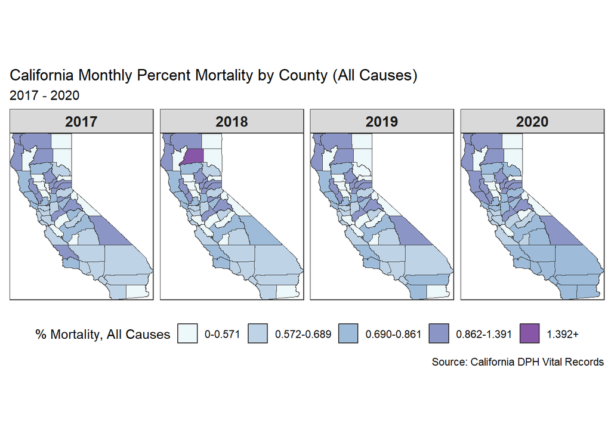

```r
##### Now add on the cuts and labels for mapping:
mortalitySummary <- mortalitySummary %>%
  mutate(deathLabels = cut(annualPercMortality,
                          breaks = c(summ, Inf),
                          labels = c("0-0.571", "0.572-0.689", "0.690-0.861",
                                    "0.862-1.391", "1.392+"),
                          ordered_result = TRUE, right = F))
```

#### Question 15 [1 points]:

What patterns do you observe now in 2020? (**NOTE**: The maps for 2017-2019 are unchanged.) Does it now feel consistent with the idea that deaths could be increasing in 2020 compared to previous years? For which counties yes but others no?

**Hint**: Take a look at counties in Southern CA, like Los Angeles, Orange, San Diego, Riverside, Imperial…

> MN: I found these plots interesting. 2017-2019 do not have too much change, aside from that one dark purple county in 2018. Looking at 2020 though, there does seem to be some dareking of the map, specifically the Southern California area, while mid to Northern California tends to remina unchanged or just a few counties that have darkened in color.

# 3 Project future mortality

Your stakeholders have asked if you can quickly give them *any* idea of what to expect mortality to be across the counties for the remaining months of 2020. Now, even though you knew it would not be the most robust method for time series projection available (**a caveat!**), you immediately think to yourself, “Oh, I could do a regression.” So, you do.

## 3.1 Regression predictions of mortality in 2020

First, you need to do a little prep to the data to get you started. You need to calculate the monthly percent mortality and attach it to your mortality shapefile, `mortality_sf2`.

```r
## First, calculate monthly percent mortality in your dataframe:
mortality_sf2 <- mortality_sf2 %>%
  ## Group by County as well as Year
  group_by(COUNTY_NAM, Year, Month) %>%
  ## Summarize by calculating a monthly percent mortality
  ## Note that I have to divide by the mean of the N from the Census
  ## or I'd get an error
  summarize(monthlyPercMortality = sum(totalDeaths,
                                       na.rm = TRUE)/mean(totalN)*100) %>%
  ## Ungroup - necessary to remove the grouping for future use
  ungroup()
```

Now, fit the OLS linear regression.

```r
olsModel <- lm(monthlyPercMortality ~ COUNTY_NAM + Year + Month, data = mortality_sf2)
```

Next, make some new data (stored into `newdata`) so you can generate predictions for those new data.

```r
## Make the new data:
## Get the names of the counties; repeat four times for the 4 months
COUNTY_NAM <- rep(unique(mortality_sf2$COUNTY_NAM), 4)
## Make a set of months for each of the 58 counties for Sept, Oct, Nov, Dec
Month <- c(rep(9, 58),
            rep(10, 58),
            rep(11, 58),
            rep(12, 58))
Year <- rep(2020, length(Month))
## Put this into a new dataframe called "newdata"
newdata <- cbind.data.frame(COUNTY_NAM, Year, Month)
```

Now, generate the predictions using `newdata` and attach the predicted monthly percent mortality to `newdata`. This is necessary for plotting to occur! Make sure you **check out the dimensions of the `newdata`**. Since you are missing four months’ of data (September - December) in 2020, there she be a row for every county for every month missing.

```r
## Attach it to the dataframe and then call it the same name as the original Y
newdata$percMortality <- predict(olsModel, newdata = newdata)
## Also, add a flag so that you know it is predicted
newdata$isPredicted <- "1"
```

Finally, you are ready to make a temporary dataframe, which you will call `temp`, which will pull everything together - the original data and the predictions - so that you can add them to your line graphs from above. Although I could choose to add the predictions to your mortality shapefile instead, I am choosing not to in order to keep that more pristine. I don’t want to add predictions that I may not use in the future to my good dataframe!

```r
temp <- totalDeaths %>%   ## Start from totalDeaths for simplicity
  ## Join with census by County
  full_join(census, by = "County") %>%
  ## Group by Year and then Month to aggregate the counties
  group_by(Year, Month) %>%
  ## Calculate the percent mortality - it is a percent because multiply by 100
  summarise(percMortality = sum(totalDeaths, na.rm = TRUE) /
              sum(totalN, na.rm = TRUE)*100) %>%
  ## Keep only the columns you need
  select(Year, Month, percMortality) %>%
  ## Make an empty flag column filled with zeros to flag if the data are
  ## predicted
  mutate(isPredicted = "0")

## Clean up newdata a little: you need to aggregate across the counties by year
newdata <- newdata %>%
  ## Group by Year and then Month to aggregate the counties; add isPredicted
  ## in there too so that it makes it into the final dataset!
  group_by(Year, Month, isPredicted) %>%
  ## Remove what you don't need
  select(-COUNTY_NAM) %>%
  ## Calculate a mean percent mortality
  summarize(percMortality = mean(percMortality, na.rm = TRUE))

## Row bind newdata onto temp to give you a complete, ordered, dataset for plots!
temp <- rbind(temp, newdata)
```

Lastly, finish out the year of 2020 with predictions (shown in bubble points):

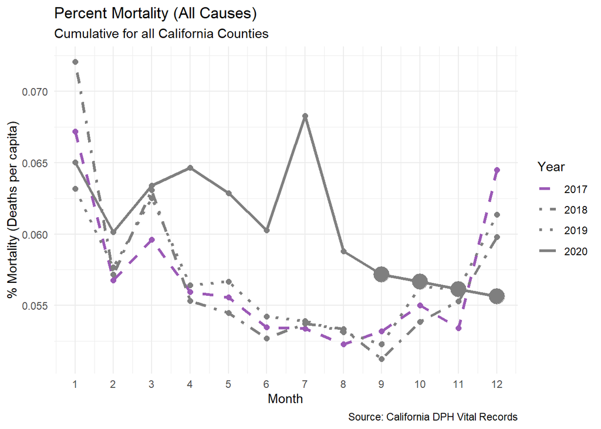

#### Question 16 [1 point]:

Do you think this regression prediction is robust? Why or why not? (**Hint**: Check your assumptions with `plot(olsModel)`!!)

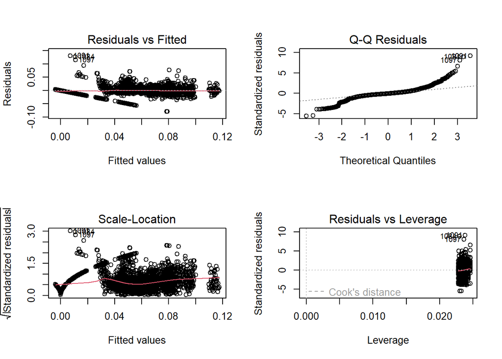

```r
par(mfrow=c(2,2))
plot(olsModel)
```

> MN: Looking at my model plots, there are a lot of things that wouldlead me to belive this is not a robust model.The Residuals vs Fitted plot has a few high leverage points or outliers that may be effecting the results. Although it looks like the plots are fairly evenly scattered otherwise.Looking at the Q-Q plot, a majority of our points follow our dashed line, but the tails on both ends are quite far off, with the high leverage points causing deviation.Scale-Location plot is some ot ideal patterns. The red line is curved, and there appears to be some deviation from homoskedascity. The final plot, Residulas vs Leverage, we see those same outliers again. I think we could make this more robust by using some spatial regressions.

## 3.2 Spatial lag regression

Then you recall that class you took during your Master’s degree - what was it called again? Doesn’t matter! You remember that calculating **spatial weights** would allow you to do a type of spatial regression, such as spatial lag regression, because it deals with **spatial autocorrelation**. Right, that was the term!

### 3.2.1 Calculate spatial weights matrix

The first step in calculating a spatial weights matrix is to ensure geometry is retained in the shapefile, even if you plan to aggregate by month or by year for mapping. I actually had you covered earlier when you first calculated the monthly percent mortality, `monthlyPercMortality`, in the **mortality shapefile**, `mortality_sf2`. By ungrouping at the end of the calculation, I ensured that you lost no data or geometry! This is also exactly WHY you did not do any aggregation directly on these data or attach the subpar predictions to `mortality_sf2`.

**Warning**: Careless aggregation WILL rob you of spatial or other information, which will make spatial modeling impossible. This is because, in order to run spatial models, the spatial object *must* retain geometry.

Now that you know you have retained all of your spatial information in `mortality_sf2`, you can create the spatial weights matrix similarly to how you did it in Demo 2 using `spdep`.

1. Create neighbor list using Queen contiguity. *This could take a minute to run, be patient.*

*This identifies which counties touch each other (using `poly2nb()`). Note, however, that you are only looking at the* **unique pairs** *of county names and geometries, however, for this step.*

```r
mortality_nb <- poly2nb(mortality_sf2 %>%
                          ## Isolate the unique county name-geometry pairs
                          select(COUNTY_NAM, geometry) %>% unique() %>%
                          ## Arrange the county names alphabetically (helps
                          ## ensure no downstream issues)
                          arrange(COUNTY_NAM) %>%
                          ## Turns the county name into a factor (helps ensure
                          ## no downstream issues)
                          mutate(COUNTY_NAM = as_factor(COUNTY_NAM)))


## Make sure the size matches the number of counties:
length(mortality_nb)
```

```
## [1] 58
```

#### Question 17A [0.5 points]

Why am I calculating the neighbors on just the **distinct counties** in the mortality shapefile when I just finished saying you don’t want to lose any of your spatial data for the model?

**Hint 1**: What are the dimensions of `mortality_sf2` and is it a multiple of 58?

**Hint 2**: What happens if I calculate spatial weights on redundant data? Does it cost me computationally?

> MN: The dimensions of mortality_sf2 is 2552 rows by 5 columns. 2552/58 = 44. We want to calculate just based on distinct neighbors, 2552 rows means that each county appears 44 times. We would create redundancy if we calculated that many times for the counties. Also, if calculating on that much redundant info, it would take longer and use much more space than needed.
2. Calculate row-standardized spatial weights matrix based on the neighbors-list. *This converts the neighbor information stored in `mortality_nb` into a usable weight list using `nb2listw()`. Neighbors have equal influence (row-standardized: `style = "W"`).*

```r
mortality_sw <- nb2listw(mortality_nb, style = "W")
```

### 3.2.2 Join spatial weights to the mortality shapefile so that every datapoint has its spatial weight.

You want to calculate, for each county in each year and month, the average percent mortality of its neighboring counties (i.e., the spatial lag). This helps you model whether mortality in one county is influenced by nearby counties. Recall from lecture and Demo 2 that a **spatial lag** is the weighted average of a variable (here, mortality) in neighboring counties. For example, if Los Angeles county is surrounded by five counties, the spatial lag for L.A. county is the average mortality rate across those five neighbors, adjusted by the spatial weights.

To accomplish this, what you need to do is loop over the time components (year and then month), and compute spatial lag for within each of the four years. you will use `purrr` to do this; it’s more computationally efficient than writing a more simple `for()` loop. As it iterates over the dataset, by year, it will use `spdep::lag.listw()` to calculate the spatial lag for each time point. The result is a new column in `mortality_sf2` that contains the average monthly mortality of any given county’s neighbors for every county-month-year combination. **Don’t forget!** You must center (not scale) the monthly percent mortality before computing the spatial weights.

```r
## Make a centered transformation of monthly percent mortality
mortality_sf2$monthlyPercMortalityCentered <- scale(mortality_sf2$monthlyPercMortality,
                                    center = TRUE, scale = FALSE)

## Initialize an empty vector to store spatial lag values
mortality_sf2$lagged_monthlyPercMortality <- NA_real_

## Calculate spatial weights for every time point
mortality_sf2 <- mortality_sf2 %>%
  arrange(COUNTY_NAM, Year, Month) %>%  ## Ensures it is in same order as weights
  ## Handles each time slice separately
  group_by(Year, Month) %>%
  mutate(
    lagged_monthlyPercMortality = {
      ## Slice to get the current group's data (i.e., one month-year combo)
      ## and then sort within group to match spatial weights
      monYr <- arrange(cur_data(), COUNTY_NAM)$monthlyPercMortalityCentered
      ## Compute the spatial lag using the spatial weights in mortality_sw
      lag.listw(mortality_sw, monYr)
    }
  ) %>%
  ungroup()
```

### 3.2.3 Run spatial lag regression using the lagged monthly mortality as a covariate

In Demo 2, you used the `spatialreg` package’s `lagsarlm()` function to perform a spatial lag regression. However, because you needed to compute the spatial lag within each year-month combo for each county, you have to perform your spatial lag regression a little differently using just the `lm()` function and explicitly using the spatially lagged monthly percent mortality ourselves.

#### Question 17B [0.25 points]

Run a **spatial lag regression (SAR)** model using the spatial lag you just calculated. Save the model as an object called `sarModel`. I have gotten it started for you so you use the spatial lag correctly, but you need to fill in the blanks, run the analysis, and assess the results.

**Hint 1**: Your target (dependent variable) is unchanged from OLS regression.

**Hint 2**: Make sure to include both time elements as covariates!

```r
sarModel <- lm(monthlyPercMortality ~ Year + Month + lagged_monthlyPercMortality,
    data = mortality_sf2 )
```

Now, let’s compare `sarModel` to `olsModel` and see which model better explains monthly percent mortality in California (uncomment to run).

```r
anova(sarModel, olsModel)
```

```
## Analysis of Variance Table
##
## Model 1: monthlyPercMortality ~ Year + Month + lagged_monthlyPercMortality
## Model 2: monthlyPercMortality ~ COUNTY_NAM + Year + Month
##   Res.Df     RSS Df Sum of Sq      F    Pr(>F)
## 1   2548 1.86374
## 2   2492 0.52334 56    1.3404 113.97 < 2.2e-16 ***
## ---
## Signif. codes:  0 '***' 0.001 '**' 0.01 '*' 0.05 '.' 0.1 ' ' 1
```

#### Question 17C [0.25 points]

Which model, the spatial lag regression (`sarModel`) or the ordinary least squares regression (`olsModel`), is a better fit to the data? Why?

> According to this comparison, it would seem that the OLS model is the better fit. I wanted it to be the sarModel, so I feel either I did not calculate correctly, or the OLS model really is better. OLS included county, so that could be the driving factor, while the sarModel used averages.

#### Question 17D [0.5 points]

Using the model you chose as the better model, `sarModel` to `olsModel`, interpret the results of that model. **HINT**: Remember that `summary()` helps you access the results from the model!

Make sure to interpret both the coefficients and their significance as well as the $R^2$!

```r
summary(olsModel)
```

```
##
## Call:
## lm(formula = monthlyPercMortality ~ COUNTY_NAM + Year + Month,
##     data = mortality_sf2)
##
## Residuals:
##       Min        1Q    Median        3Q       Max
## -0.079173 -0.005078 -0.000844  0.004420  0.130845
##
## Coefficients:
##                             Estimate Std. Error t value Pr(>|t|)
## (Intercept)               -1.405e+00  5.499e-01  -2.556 0.010653 *
## COUNTY_NAMAlpine          -5.113e-02  3.090e-03 -16.548  < 2e-16 ***
## COUNTY_NAMAmador           2.760e-02  3.090e-03   8.933  < 2e-16 ***
## COUNTY_NAMButte            4.411e-02  3.090e-03  14.276  < 2e-16 ***
## COUNTY_NAMCalaveras        1.536e-02  3.090e-03   4.972 7.09e-07 ***
## COUNTY_NAMColusa          -2.105e-02  3.090e-03  -6.814 1.19e-11 ***
## COUNTY_NAMContra Costa     4.857e-03  3.090e-03   1.572 0.116103
## COUNTY_NAMDel Norte        3.448e-02  3.090e-03  11.160  < 2e-16 ***
## COUNTY_NAMEl Dorado        6.635e-03  3.090e-03   2.147 0.031855 *
## COUNTY_NAMFresno           1.190e-02  3.090e-03   3.852 0.000120 ***
## COUNTY_NAMGlenn           -7.350e-03  3.090e-03  -2.379 0.017443 *
## COUNTY_NAMHumboldt         2.723e-02  3.090e-03   8.814  < 2e-16 ***
## COUNTY_NAMImperial        -7.064e-03  3.090e-03  -2.286 0.022314 *
## COUNTY_NAMInyo             2.907e-02  3.090e-03   9.408  < 2e-16 ***
## COUNTY_NAMKern             4.537e-03  3.090e-03   1.468 0.142133
## COUNTY_NAMKings           -5.385e-03  3.090e-03  -1.743 0.081465 .
## COUNTY_NAMLake             2.739e-02  3.090e-03   8.867  < 2e-16 ***
## COUNTY_NAMLassen          -1.891e-02  3.090e-03  -6.120 1.09e-09 ***
## COUNTY_NAMLos Angeles      4.759e-03  3.090e-03   1.540 0.123643
## COUNTY_NAMMadera          -2.881e-03  3.090e-03  -0.933 0.351139
## COUNTY_NAMMarin            1.316e-02  3.090e-03   4.259 2.13e-05 ***
## COUNTY_NAMMariposa         1.542e-03  3.090e-03   0.499 0.617756
## COUNTY_NAMMendocino        1.909e-02  3.090e-03   6.178 7.55e-10 ***
## COUNTY_NAMMerced          -9.876e-03  3.090e-03  -3.196 0.001409 **
## COUNTY_NAMModoc           -4.198e-02  3.090e-03 -13.589  < 2e-16 ***
## COUNTY_NAMMono            -5.113e-02  3.090e-03 -16.548  < 2e-16 ***
## COUNTY_NAMMonterey        -1.995e-03  3.090e-03  -0.646 0.518429
## COUNTY_NAMNapa             2.691e-02  3.090e-03   8.709  < 2e-16 ***
## COUNTY_NAMNevada           2.985e-02  3.090e-03   9.663  < 2e-16 ***
```

[output cut: 22 more lines]

```
## COUNTY_NAMTehama           1.616e-02  3.090e-03   5.231 1.83e-07 ***
## COUNTY_NAMTrinity         -3.561e-02  3.090e-03 -11.526  < 2e-16 ***
## COUNTY_NAMTulare           1.359e-03  3.090e-03   0.440 0.660174
## COUNTY_NAMTuolumne         4.502e-02  3.090e-03  14.572  < 2e-16 ***
## COUNTY_NAMVentura          4.888e-03  3.090e-03   1.582 0.113733
## COUNTY_NAMYolo            -5.726e-03  3.090e-03  -1.853 0.063978 .
## COUNTY_NAMYuba             3.307e-02  3.090e-03  10.703  < 2e-16 ***
## Year                       7.232e-04  2.724e-04   2.655 0.007981 **
## Month                     -5.177e-04  8.654e-05  -5.982 2.52e-09 ***
## ---
## Signif. codes:  0 '***' 0.001 '**' 0.01 '*' 0.05 '.' 0.1 ' ' 1
##
## Residual standard error: 0.01449 on 2492 degrees of freedom
## Multiple R-squared:  0.723,  Adjusted R-squared:  0.7165
## F-statistic: 110.3 on 59 and 2492 DF,  p-value: < 2.2e-16
```

```r
summary(sarModel)
```

```
##
## Call:
## lm(formula = monthlyPercMortality ~ Year + Month + lagged_monthlyPercMortality,
##     data = mortality_sf2)
##
## Residuals:
##       Min        1Q    Median        3Q       Max
## -0.064410 -0.010521  0.000657  0.015843  0.116780
##
## Coefficients:
##                               Estimate Std. Error t value Pr(>|t|)
## (Intercept)                 -1.7386943  1.0288619  -1.690 0.091166 .
## Year                         0.0008920  0.0005097   1.750 0.080223 .
## Month                       -0.0006300  0.0001634  -3.857 0.000118 ***
## lagged_monthlyPercMortality -0.2190860  0.0478683  -4.577 4.95e-06 ***
## ---
## Signif. codes:  0 '***' 0.001 '**' 0.01 '*' 0.05 '.' 0.1 ' ' 1
##
## Residual standard error: 0.02705 on 2548 degrees of freedom
## Multiple R-squared:  0.01361,    Adjusted R-squared:  0.01245
## F-statistic: 11.72 on 3 and 2548 DF,  p-value: 1.27e-07
```

#### Question 17E [0.25 points]

Can you trust the results of the model? Why or why not?

```r
## Your code here.
```

> MN: I feel that the olsModel is a good baseline model based on the higher R-squared result, and statistically significant coefficient results, but there is room for improvement. There is no spatial autocorrelation showing how counties influence each other, and there could be omitted variables underlying county name. Therefore, I don’t feel we can entirely trust this model.

# 4 Improve Predictions with Machine Learning

You are growing increasingly concerned that you will not be able to provide robust predictions to your stakeholder, and you’re feeling nervous - it is a new job, after all! So, you think about other ways to try to **improve the prediction**. Although you technically can’t see into the future, right now, you and I can - which is exactly what you are going to do! Unlike the random splits you have done before, you are actually going to perform what is called a **time-aware split**, where you use January 2017 to December 2019 as your training data and January to August 2020 as your testing data. This approach accounts for *temporal structure* in the data, as well as spatial structure in the data by using the lagged mortality you computed above as a spatial proxy.

*Perform a time-aware train-test split*

```r
## Make the training data
mortalityTrain <- mortality_sf2 %>%
  ## Drop the geometry to make processing downstream faster
  st_drop_geometry() %>%
  ## Filter for just the year-month combos you want
  filter(Year != 2020) %>%
  ## Drop the previously centered monthly percent mortality from when you made
  ## the spatial weights matrix
  select(-monthlyPercMortalityCentered)

## Make the testing data
mortalityTest <- mortality_sf2 %>%
  ## Drop the geometry to make processing downstream faster
  st_drop_geometry() %>%
  ## Filter for just the year-month combos you want
  filter(Year == 2020) %>%
  ## Drop the previously centered monthly percent mortality from when you made
  ## the spatial weights matrix
  select(-monthlyPercMortalityCentered)
```

#### Question 18A [0.5 points]

What percent of the data are in the training set and what percent in the testing set? You should use code to figure this out! How does it compare to the canonical 80-20 split?

```r
round(100 * c(
  train <- nrow(mortalityTrain) / (nrow(mortalityTrain) + nrow(mortalityTest)),
  test <- nrow(mortalityTest) / (nrow(mortalityTrain) + nrow(mortalityTest))
), 2)
```

```
## [1] 81.82 18.18
```

> MN: With a train/test spli of 81.82 and 18.18, this is very close to 80/20, and I feel this is still a safe split ratio to continue.

#### Question 18B [0.5 points]

What caveats or limitations can you think of by using none of the 2020 data in the training set?

> MN; While 2020 was a stand-out year and far from typical, leaving it out could provide some limitations. Reduced training set size which would mean weaker estimations of seasonal trends, and if the model only learns trends prior to 2020, it could under predict mortality in the pandemic era data.

## 4.1 Fitting an out-of-bag (OOB) random forest (RF) model

You decide to use random forest (RF) for this task because it handles non-linearity, which you know you have from your time plots above AND from the summaries of both your OLS and SAR regressions. You also choose to use RF because it can be more robust to outliers and still give some idea of importance for interpretability for your stakeholders. Your basic workflow will be to:

1. Center and scale the predictors
2. Fit the model with OOB error
3. Fit the model with 10-fold cross-validation
4. Compare the RMSE of the two models
5. Show the variable importance of the final model

You decide to leverage the `caret` package in R again for much of your model fitting and tuning needs. If you want to know more about what `caret` does and doesn’t do, this [chapter](https://daviddalpiaz.github.io/r4sl/the-caret-package.html) can help.

#### Question 19A [0.5 points]

What does it mean to “fit a model with out-of-bag (OOB) error”? Why do we do it? What can it tell you here?

> MN: Out-of-bag error is a technique to check how good model is without having a separate test set. It can give a quick reference for model performance, and helps to avoid overfitting.

Even though you have no encoding, you know that you need to center and scale your data before running the random forest! So, you decide to leverage the `preProcess()` function in the `caret` package to help you center and scale the predictors. You perform the preprocessing explicitly here, storing the pre-processed training *instructions* in `preProcInstructions`. Then, you can apply the pre-processing to the training data, `mortalityTrain`, using the `predict()` function. Note that this is a different step than when you are predicting from a model for performance evaluation!

```r
## First, make a new object, preProcInstructions, that stores the
## pre-processing instructions from mortalityTrain:
preProcInstructions <- preProcess(mortalityTrain,
                                    method = c("center", "scale"))

## Now apply the pre-processing instructions using predict()
mortalityTrain <- predict(preProcInstructions,
                                      newdata = mortalityTrain)
```

Then, you fit the OOB RF model after using the `trainControl()` function to tell it to fit the training model with OOB error.

*Fit an OOB random forest (RF) model*

```r
## Define training control for OOB
ctrlOOB <- trainControl(method = "oob")

## Define the tuning grid
tuneGrid <- expand.grid(mtry = 1:3)  ## Coerce it to use mtry 1 through 3

## Run the OOB random forest, including preprocessing instructions
rfOOB <- train(
  ## Define the model - everything but COUNTY_NAM
  monthlyPercMortality ~ Year + Month + lagged_monthlyPercMortality,
  ## Set the data
  data = mortalityTrain,
  ## Indicate that it is a random forest
  method = "rf",
  ## Indicate the training control method to use, defined above
  trControl = ctrlOOB,
  ## Indicate that you want to extract importance at the end
  importance = TRUE,
  ## Indicate the tuning grid, defined explicitly above
  tuneGrid = tuneGrid
)
```

Note that here you coerce it to use an `mtry` hyperparameter grid search of 1 through 3. This is just because you have a really non-complex dataset (only 3 predictors!) and you want to force it to run *as if* it had a little more complexity. Why? Just to make sure it searches long enough!

#### Question 19B [0.5 points]

What is `mtry` and what is it doing in the context of a random forest? What is the default `mtry` for a random forest regression? Why am I choosing to override it here, do you think?

> MN: The mtry is number of variables selected at each split to find the best one. The default mtry for an RF regression is the number of predictors divinded by 3. https://parsnip.tidymodels.org/reference/details_rand_forest_randomForest.html We are trying to overide it because we want to find the best spot between bias and variance. If the default mtry was left alone, it would only use 1.

*Look at the results ($RMSE$ and $R^2$) of the OOB random forest*

```r
rfOOB$results %>%
  kable(
    format = "html",
    caption = "Table 3. Results of the OOB random forest on California Mortality (All Causes).") %>%
    kable_styling(bootstrap_options = c("hover"))
```

Table 3. Results of the OOB random forest on California Mortality (All Causes).

| RMSE | Rsquared | mtry |
| --- | --- | --- |
| 0.9846101 | 0.0300785 | 1 |
| 1.0287900 | -0.0589161 | 2 |
| 1.0592534 | -0.1225554 | 3 |

Recall from the Elastic Net you fitted a couple weeks ago on the hospital readmissions data that you optimized a hyperparameter, $\lambda$, to get the best-tuned model. It is the same idea here with `mtry`. Remember, optimized results will be the **lowest error** as measured by Root Mean-Squared Error ($RMSE$) and the highest percent of the variance in the target explained, $R^2$. In other words, you want a model that uses as much information as it can, which results in lower error, and betters your chances that it will return a good prediction!

#### Question 19C [0.5 points]

Which value of `mtry` gave the best results? (**Hint**: Can $R^2$ values be negative?!?). Are you able to compare the $RMSE$ of this model to the one you fitted in Question 16C? Why or why not? (**Hint**: Does your pre-processing step apply to the target too? You may have to do a little research!)

## 4.2 Fitting a 10-fold cross-validated random forest (RF) model

You now feel decide to move forward with the 10-fold cross-validation. Remember that this is to **help control for overfitting**, which you can identify by looking at the error ($RMSE$) and fit ($R^2$) in each of the folds.

*Define the training control method as 10-fold cross-validation (CV) and run the model*

```r
## Define training control for 10-fold cross-validation
ctrlCV <- trainControl(method = "cv", number = 10)

## Run the 10-fold CV random forest, including preprocessing instructions
rfCV <- train(
  ## Define the model
  monthlyPercMortality ~ Year + Month + lagged_monthlyPercMortality,
  ## Set the data
  data = mortalityTrain,
  ## Indicate that it is a random forest
  method = "rf",
  ## Indicate the training control method to use, defined above
  trControl = ctrlCV,
  ## Indicate that you want to extract importance at the end
  importance = TRUE,
  ## Indicate the tuning grid, defined explicitly earlier
  tuneGrid = tuneGrid
)
```

```r
rfCV$results %>%
  kable(
    format = "html",
    caption = "Table 4. Results of the 10-fold CV random forest on California Mortality (All Causes).") %>%
    kable_styling(bootstrap_options = c("hover"))
```

Table 4. Results of the 10-fold CV random forest on California Mortality (All Causes).

| mtry | RMSE | Rsquared | MAE | RMSESD | RsquaredSD | MAESD |
| --- | --- | --- | --- | --- | --- | --- |
| 1 | 0.9813722 | 0.0402551 | 0.7055576 | 0.0362350 | 0.0259631 | 0.0300309 |
| 2 | 1.0262523 | 0.0252655 | 0.7610013 | 0.0241068 | 0.0207770 | 0.0231511 |
| 3 | 1.0507399 | 0.0220137 | 0.7865539 | 0.0268171 | 0.0207378 | 0.0239785 |

#### Question 19D [0.5 points]

What do you notice about the effects of cross-validation on your model? (**Hint**: Do you see any negative $R^2$ values this time?) Which value of `mtry` gave the best results? How does the $RMSE$ of that model compare to the one you chose as the optimal OOB model?

## 4.3 Test the training model with the 2020 data

### 4.3.1 Preprocess your test data with the same centering/scaling

Since you used `caret`’s `preProcess()` during model training, then you also have to apply the same transformation to your testing data for predictions!

Notice that you will *first* store the pre-processed values for the training set in its own object, `preProcInstructions`, and then you apply the same pre-processing on the training set using the `predict()` function. This is **separate** from the predictions you will make on the testing set using the model!

```r
## Apply the same preprocessing as training using predict(),
## using the test data
mortalityTest <- predict(preProcInstructions, newdata = mortalityTest)
```

### 4.3.2 Predict using the best RF model

An advantage of using `caret` is that it will automatically identify your best model for us, which you can access by simply using the model object `rfCV` with `predict()`. **Make sure you think about why you are using `rfCV` and not `rfOOB` here!**

```r
## Predict on pre-processed test data using the best trained RF model
rfPredictions <- predict(rfCV, newdata = mortalityTest)
```

### 4.3.3 Evaluate performance with $RMSE$ and $MAE$

`caret` also has built-in functions to calculate key performance metrics, like $RMSE$ and $MAE$ for regression models or a confusion matrix with accuracy for classification models. You can read more about them in this [chapter](https://topepo.github.io/caret/measuring-performance.html).

```r
### Compute RMSE (Root Mean Squared Error)
rfRMSE <- RMSE(pred = rfPredictions, obs = mortalityTest$monthlyPercMortality)

## Compute MAE (Mean Absolute Error) as well, optionally
rfMAE <- MAE(pred = rfPredictions, obs = mortalityTest$monthlyPercMortality)

## Print results
print(paste0("Random Forest Test RMSE:   ", round(rfRMSE, 4)))
```

```
## [1] "Random Forest Test RMSE:   1.0081"
```

```r
print(paste0("Random Forest Test MAE:    ", round(rfMAE, 4)))
```

```
## [1] "Random Forest Test MAE:    0.743"
```

#### Question 19E [0.5 points]

Can you interpret the $RMSE$ and $MAE$ values? **Remember** all of the data were subject to pre-processing, both target and predictors!

**How did the training model perform?** Does it seem to be overfitting (training error >> testing error), underfitting (training error and testing error both high but roughly equal with a low $R^2$), or doing okay?

### 4.3.4 Plot Actual vs. Predicted Values

Unimpressed with the results so far, you decide to plot the actual vs. predicted values because that can tell you whether your training model is likely leading to an **under prediction** or an **over prediction** relative to the true values of mortality. Using the `ggExtra` package, you add histograms to the margins of the scatterplot as well to help you interpret correctly.

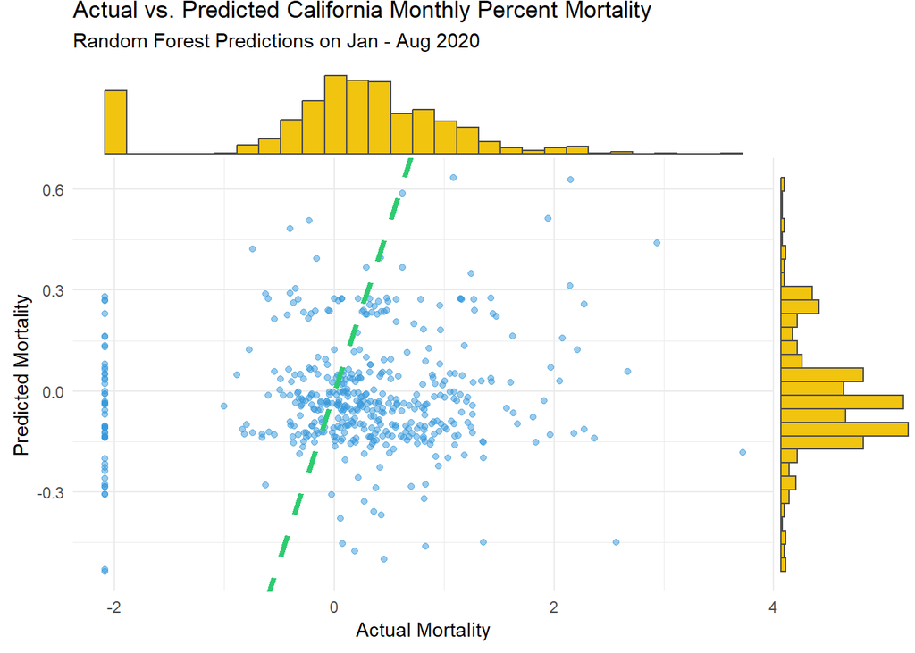

```r
## Make a scatterplot of the actual vs. predicted values
p <- ggplot(mortalityTest, aes(x = monthlyPercMortality, y = rfPredictions)) +
  ## Scatteplot with geom_point
  geom_point(alpha = 0.5, color = skittles[4]) +
  ## Add a line to help see the general trend
  geom_abline(color = skittles[3], linetype = "dashed", size = 1.5) +
  theme_minimal() +
  labs(
    title = "Actual vs. Predicted California Monthly Percent Mortality",
    subtitle = "Random Forest Predictions on Jan - Aug 2020",
    x = "Actual Mortality",
    y = "Predicted Mortality"
  )
## Add marginal histograms with the ggExtra package
ggMarginal(p, type = "histogram", fill = skittles[2], color = "gray30")
```

#### Question 19F [0.5 points]

Interpret the scatterplot of the actual vs. predicted values. What is happening to the predicted values? (Use the histogram on the side to help you, that’s why they’re there!) Make sure to mention whether the training model is leading to an **under prediction** or an **over prediction** of mortality. What **real information** might that provide your stakeholders, even if the model is underperforming?

> MN: I think what this plot is showing is that actual mortality values look more evenly spread across, while the predicted mortality values are more centered around the 0 to -0.25 area, when comparing the histograms. I would say this model under predicting high mortality and over predicting low mortality. This could still be valuable to stakeholders because we can go back and with limitations of current data and ask for better or newer data and predictors. There is more to the story.

## 4.4 Extract variable importance from the final model

You also decide to extract the variable importance from the final trained model to share with your stakeholders.

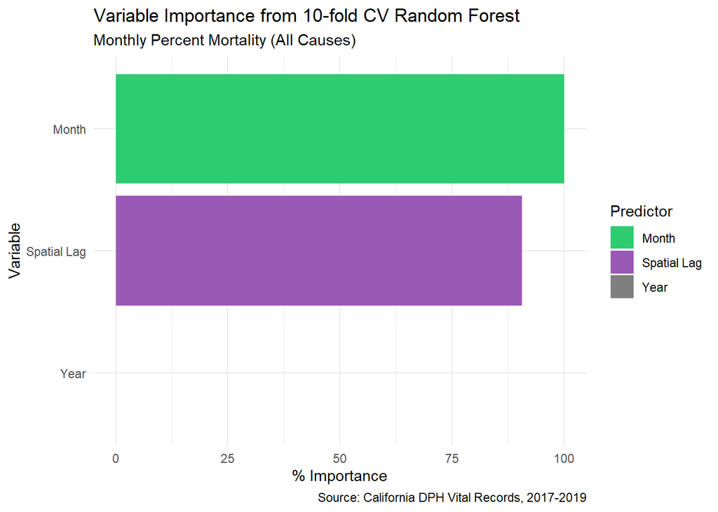

|  | Overall |
| --- | --- |
| Year | 0.00 |
| Month | 100.00 |
| lagged_monthlyPercMortality | 90.57 |

## 4.5 Comparing your predictions to the real deaths data

Now, let’s pretend that you’re skipping ahead a few months in time and you’re actually able to assess just how well your prediction could do in reality. While what you *could* do is fit a 10-fold, cross-validated random forest on all of the data and download the remaining months of 2020 and use all of 2020 as your test dataset, instead I’m just going to ask you to do a simple correlation to see how badly - or well - it did in reality.

#### Question 19G [5 points]

> MN:

Since the pandemic is over in reality, you can find the actual number of deaths, per county, [here](https://data.chhs.ca.gov/dataset/death-profiles-by-county/resource/579cc04a-52d6-4c4c-b2df-ad901c9049b7).

**Hint**: You can read this file in as a dataframe using `read.csv()` as follows! I also show you the structure (`str()`) of the data so you have an idea what you’re getting.

```r
#caliDeaths <- read.csv("https://s3.amazonaws.com/og-production-open-data-chelseama-892364687672/resources/078185a9-e3a7-403f-a546-b8c582f0a9d8/20241220_deaths_final_2019-2023_occurrence_county_month_sup.csv?X-Amz-Algorithm=AWS4-HMAC-SHA256&X-Amz-Credential=AKIAJJIENTAPKHZMIPXQ%2F20250615%2Fus-east-1%2Fs3%2Faws4_request&X-Amz-Date=20250615T190154Z&X-Amz-Expires=86400&X-Amz-SignedHeaders=host&X-Amz-Signature=61c4009b5979f2d74a95396e2f77ace3d13315fe166588cb1210ef46d292f759")

#caliDeaths %>%
 # str()


##JML figured out this code
filters <- URLencode('{"Year":"2020","Cause":"ALL"}')
url <- paste0('https://data.chhs.ca.gov/api/3/action/datastore_search?resource_id=078185a9-e3a7-403f-a546-b8c582f0a9d8&limit=50000&filters=', filters)

caliDeaths <- fromJSON(url)

caliDeaths <- caliDeaths$result$records

caliDeaths %>%
  str()
```

```
## 'data.frame':    19488 obs. of  14 variables:
##  $ _id               : int  126673 126674 126675 126676 126677 126678 126679 126680 126681 126682 ...
##  $ Year              : chr  "2020" "2020" "2020" "2020" ...
##  $ Month             : chr  "01" "01" "01" "01" ...
##  $ County            : chr  "Alameda" "Alameda" "Alameda" "Alameda" ...
##  $ Geography_Type    : chr  "Occurrence" "Occurrence" "Occurrence" "Occurrence" ...
##  $ Strata            : chr  "Total Population" "Age" "Age" "Age" ...
##  $ Strata_Name       : chr  "Total Population" "Under 1 year" "1-4 years" "5-14 years" ...
##  $ Cause             : chr  "ALL" "ALL" "ALL" "ALL" ...
##  $ Cause_Desc        : chr  "All causes (total)" "All causes (total)" "All causes (total)" "All causes (total)" ...
##  $ ICD_Revision      : chr  "ICD-10" "ICD-10" "ICD-10" "ICD-10" ...
##  $ Count             : chr  "973" NA NA "0" ...
##  $ Annotation_Code   : chr  NA "1" "1" NA ...
##  $ Annotation_Desc   : chr  NA "Cell suppressed for small numbers" "Cell suppressed for small numbers" NA ...
##  $ Data_Revision_Date: chr  "12/20/2024" "12/20/2024" "12/20/2024" "12/20/2024" ...
```

**Remember** to filter for the proper condition, Year, and Months to get the data you need. Take time to explore the data, and make sure that you are matching the data we’ve been using (total mortality, all causes of death) to your filter.

```r
## See above
```

Now make sure to compute the **monthly percent mortality** as you have done before. Otherwise, you won’t be comparing apples-to-apples! >MN:

```r
#wanted to not mess up my good census dataframe
census_clean <- census %>%
  distinct(County, .keep_all = TRUE)

caliDeaths <- caliDeaths %>%
  mutate(Count = as.numeric(Count))  #converts character to numeric, turning "NA" into NA
##### Calculate the monthly percent mortality
mortalitySummary_cali_deaths <- caliDeaths %>%
  left_join(census_clean, by = "County") %>%
  ## Group by County as well as Year
  group_by(County, Month) %>%
  ## Summarize by calculating a monthly percent mortality
  ## Note that I have to divide by the mean of the N from the Census
  ## or I'd get an error
  summarize(monthlyPercMortality_new = sum(Count,
                                       na.rm = TRUE)/mean(totalN)*100) %>%
  ## Ungroup - necessary to remove the grouping for future use
  ungroup() #%>%
  ## NOW, you can group again by county and year and calculate the true annual
  ## average that has been adjusted for differing number of months!
  #group_by(County, Year) %>%   ## <- no Month now!
  #summarize(annualPercMortality_new = mean(monthlyPercMortality_new, na.rm = TRUE)*12)

#### Find the five number summary
summ_cali_deaths <- fivenum(mortalitySummary_cali_deaths$monthlyPercMortality_new)
paste0("The five-number summary of monthly % total mortality is: ")
```

```
## [1] "The five-number summary of monthly % total mortality is: "
```

```r
paste(c("Min", "Lower Quartile", "Median", "Upper Quartile", "Max"),
      round(summ_cali_deaths, 3))
```

```
## [1] "Min 0"                "Lower Quartile 0.2"   "Median 0.294"
## [4] "Upper Quartile 0.353" "Max 0.8"
```

```r
##### Now add on the cuts and labels for mapping:
mortalitySummary_cali_deaths <- mortalitySummary_cali_deaths %>%
  mutate(deathLabels = cut(monthlyPercMortality_new,
                          breaks = c(summ_cali_deaths, Inf),
                          labels = c("0-0.571", "0.572-0.689", "0.690-0.861",
                                    "0.862-1.391", "1.392+"),
                          ordered_result = TRUE, right = F))
```

Lastly, create (1) a scatterplot with trend line and (2) perform a correlation test on your **Sept to December 2020** predictions relative to the true **Sept to December 2020** monthly percent mortality. >MN:

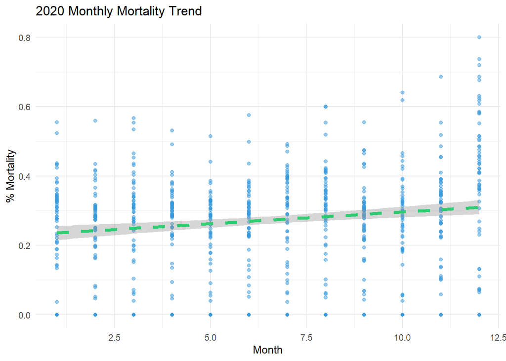

```r
# Filter to Sept–Dec 2020
plot_data <- mortalitySummary_cali_deaths %>%
  filter(Month %in% c("09", "10", "11", "12"))

#wanted to plot month as continuous so my trend line would follow the data
mortalitySummary_cali_deaths$Month <- as.numeric(mortalitySummary_cali_deaths$Month)

#updated plot
plot2 <- ggplot(mortalitySummary_cali_deaths, aes(x = Month, y = monthlyPercMortality_new)) +
  geom_point(alpha = 0.5, color = skittles[4]) +
  geom_smooth(method = "lm", color = skittles[3], linetype = "dashed", se = TRUE, size = 1.5) +
  theme_minimal() +
  labs(
    title = "2020 Monthly Mortality Trend",
    x = "Month",
    y = "% Mortality"
  )

print(plot2)
```

```r
corr_data <- plot_data %>% #to perform the correlation test I need the same length of values
  group_by(Month) %>%
  summarize(actual = mean(monthlyPercMortality_new, na.rm = TRUE)) %>%
  mutate(Month = as.numeric(Month))

corr_joined <- inner_join(corr_data, temp, by = "Month") #join dataframes so that i can perform correlation test

#filter to Sept–Dec 2020 before correlation test
corr_filtered <- corr_joined %>%
  filter(Year == 2020, Month %in% c(9, 10, 11, 12))

cor.test(corr_filtered$actual, corr_filtered$percMortality)
```

```
##
##  Pearson's product-moment correlation
##
## data:  corr_filtered$actual and corr_filtered$percMortality
## t = -2.6155, df = 2, p-value = 0.1204
## alternative hypothesis: true correlation is not equal to 0
## 95 percent confidence interval:
##  -0.9974623  0.5268305
## sample estimates:
##        cor
## -0.8796495
```

**For full credit** include a brief interpretation of your findings. >MN: According to the scatterplot, the trend line has a slight upward path from roughly month 3-12. While I was expeting a more dramatic slope, there is obviously an upward trend. Looking at the correlation test, the correlaton coefficient is -0.88, so as predicted values go up, actual values tend to go down. A high p-value would suggest thatthis is not significant. There are also only 4 values, so not a lot of data to go on.

#### Question 19H [1 point]

By now, it should be clear that there is a **monthly seasonality** to deaths that has nothing to do with what year it is, even though 2020 was a pandemic year. In fact, that seasonality is so strong that it ends up as a very strong predictor - about as strong as the spatial autocorrelation! Although I wish I could dive into that with you deeply now, I would not be able to do the topic justice. Note that Merrimack offers an entire course on time series - but if you are unable to take the course but want to learn more on your own, one resource I can recommend is [A Little Book of R For Time Series by Avril Coghlan](https://app.readthedocs.org/projects/a-little-book-of-r-for-time-series/downloads/pdf/latest/).

Since you can’t go deeply into doing it, instead you will do a little reading/research. I suggest reading about *temporal autocorrelation* or *seasonal momentum* and how adding time-series lags can help. How might time series lags capture what the “Month” variable alone may not fully capture, in a similar way to how “County” alone may not fully capture spatial relationships?

**Note**: Doing the time-aware data partition into before 2020 and after 2020 IS a form of controlling for temporal patterns/seasonality, albeit not as robust as including temporally lagged variables.

> > MN: Using a predictor such as Month alone, may not fully capture the full picture because it is just telling you when something occured as opposed to the history behind it, or causes. The same for County, it can tell you where something happened but not history of county insights. A time-series lag can capture past trends leading up to current data, and how current data is correlated to past data. https://www.geeksforgeeks.org/machine-learning/what-is-lag-in-time-series-forecasting/

#### Question 19I [1 point]

**Would you like to see how I got this?** This source code contains all of the steps of analysis, with comments, and will show you these same results! Make sure to open the source code if you want to see the step-by-step instructions and not just the output! In brief, what I do is engineer temporal lag and rolling means features to inform the model how the target behaved in the past. Lags are explicitly accounting for temporal autocorrelation; rolling averages show recent trends and smooth noise. Then, I do the time-aware split again using the 2020 data as my holdout testing set. I then add the lagged and rolling means features, along with the spatial lag, month, and year variables as predictors to the RF model and assess performance on the testing holdout set. Note that RF is a particularly good choice for temporal models because it is non-linear; further, adding lags makes it partially time-aware. **However, don’t forget to ALWAYS validate with time held out, not random sampling, in temporal models!**

```r
source("mortalityTemporalLagRF.R")
```

[output not shown]

#### Question 19J [1 point]

What is something **else** you can do to improve your model that you have not discussed or explored at all here? **Hint**: Random forest models need complexity!

> MN: We could use some interactions between predictors instead of just treating them as independant factors. Perhaps treating the months as quarters(seasons, pre/post-holiday) and treating the counties as rural or urban. I think creativity is the limit with feature engineering.

#### Question 19K [3 points]

Take all of the findings and interpretations from questions 18A-J and write up a short paragraph or two summary for your stakeholders. Your writing should not be overly technical but it should include caveats and limitations. Make sure to include 1-2 sentences of recommendations about what you would do next.

> MN: The model’s initial predictions didn’t align closely with the actual data. The estimates were off by a noticeable margin. After adding new features that help the model learn from past months, accuracy improved dramatically. The predictions are now much closer after adjusting for time. That said, when we looked specifically at September through December 2020, the relationship between predicted and actual values wasn’t as strong as expected. With only four data points, it’s hard to draw firm conclusions. Next steps: we recommend exploring region-specific seasonal patterns and layering in additional data sources like population changes, or social determinants of health. This would help the model become more resilient with public health planning.

# 5 Zooming in on Mortality Causes

California was one of the strictest states when it came to shutdown measures during the COVID-19 pandemic, with both statewide enforcement and a duration longer than some other states in the country. California declared a state of emergency on **March 4, 2020** with a a mandatory statewide stay-at-home order issued on **March 19, 2020**. This statewide order didn’t end until **January 25, 2021**, but it still wouldn’t be until April 6, 2021 when the state announced plans to fully reopen the economy by **June 15, 2021**.

Your stakeholder is actually not as interested in deaths from COVID-19, but actually more interested in how the mandatory stay-at-home order seems to affecting mortality due to certain conditions. **For example, are people less likely to die from accident or injury since they’re under stay-at-home orders?**

## 5.1 Death from Accident & Injury

Because of the mandatory COVID-19 shutdown in California, which has led to generally reduced movement throughout California, your stakeholder would like to know if the number of accidental deaths declined enough **during COVID-19 shutdown** to generate a signal.

**HYPOTHESIS**: You hypothesize that because of intense, mandatory stay-at-home measures, deaths attributed to accidents and injuries (`INJ`) declined during the COVID-19 shutdown during the months of 2020 in California.

You will start, as with all good analysis plans, with some more **Exploratory Data Analysis**.

### 5.1.1 Sex-specific Effects on `INJ` Mortality

#### 5.1.1.1 Total Deaths by Sex

Your stakeholder asks you to be sure to **stratify by the sex of the decedent**, because they suspect there is a difference in death rates by the decedent’s biological sex.

The leading causes of death are located in the `sexDeaths` table because that was how the data were provided to you. They are separated by sex, thus you can check to see if there are sex differences that could matter for your analysis. You need to join some of your tables and calculate some additional metrics as well, including:

- Proportion of deaths from accident or injury out of all deaths (no longer adjusting for population size)
- Ratio of adult females to males in the population
- Ratio of females to males in the population among those over 65 years of age
- Ratio of all adults over the age of 65 (retirement age) to those under retirement age

You have opted to adjust per total deaths, rather than population size, so that you can better examine the fraction of deaths due to particular causes regardless of the underlying size of the population. However, you need to account for the ratio of females to males in the population, as it might be useful now or in future analyses to have access to the ratio of females to males. Similarly, having the ratio of retirees in the population (those over the age of 65 year) relative to non-retirees in the population may also be useful in future analyses. Further, the size of a county may still matter; so you will likely want to retain the total sample size of the county as a control variable as well. Note that, in a more detailed analysis, **population density** would be better than population size, but this is the proxy of county size you currently have to work with!

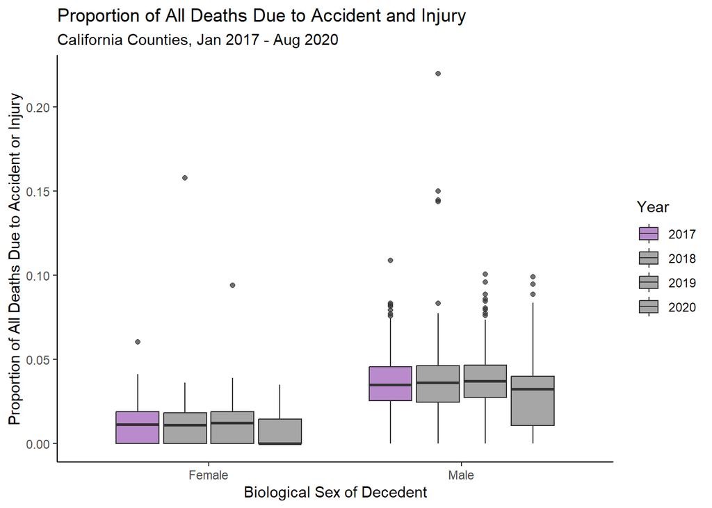

```r
## Join the sex deaths table with the census data; then filter for INJ
injDeaths <- sexDeaths %>%
  full_join(census, by = "County") %>%
  ## Here is where you filter for a specific cause of death relative to sex
  filter(leadingCauseDeath == "INJ") %>%
  ## Now full join with the first 4 columns of the totalDeaths table to get
  ## total deaths also
  full_join(totalDeaths[ , 1:4], by = c("County", "Year", "Month")) %>%
  ## Rename the sexDeaths column to something more appropriate
  rename(injuryDeaths = sexDeaths) %>%
  ## Calculate the proportion of all deaths that are from injury
  ## RELATIVE TO ALL DEATHS (not population!!)
  mutate(deathsInjuriesProportion = injuryDeaths/totalDeaths,
         ## The ratio of females to males in the population
         femaleMaleRatio = femalesN/malesN,
         ## The ratio of 65+ females to males in the population
         femaleMaleRatio65 = females65plus/males65plus,
         ## Ratio of retirees to non-retirees
         retireeRatio = over65/totalN,
         ## Convert the date to a date format for plotting
         Date = as.Date(paste(Year, Month, "1", sep = "-"),
                        format = "%Y-%m-%d")) %>%
         ## Illegal div by 0 turned to NaN; turn back to 0
  mutate(deathsInjuriesProportion = ifelse(deathsInjuriesProportion == "NaN",
                                           0, deathsInjuriesProportion))
```

#### Question 20A [0.5 points]:

Would it be fair to model the proportion of deaths due to injury or accident without accounting for an effect of sex? Why or why not?

> MN: I think that you could not bring sex into the proportion if you only were interested in overall numbers. By seperating the genders, you can see a pattern of death between the two, with females clearly being lower across all years. I think there is value in that information and could be helpful in further analysis. If we lumped both genders together, with males being so much higher than females, this could cause some disproportionate results.

#### 5.1.1.2 Proportion of Deaths by Sex

What if you calculate the proportion of deaths, for each sex, instead? Wouldn’t that give you a more accurate portrait of any sex-level differences that might exist?

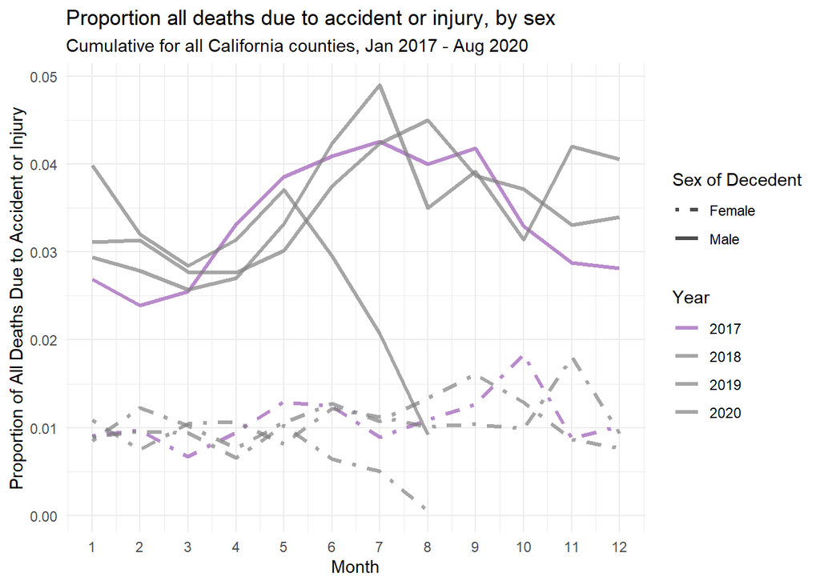

#### Question 20B [0.5 points]:

What do you notice about the trend? Is there anything compelling here? Can you find any possible explanation for what happened in May (month 5) of 2020?

> MN: Overall, males are still much higher than females. Aside from 2020, both groups follow similar trends year to year. The possible cause of the May 2020 drop could be due in fact to the stay at home orders. Though that is 2 mpnths after the issue of that order, so could be another cause?

### 5.1.2 Mapping injury-related deaths by stay-at-home orders & sex

So, hopefully you’ve noticed what I’ve noticed about the relationship between the stay-at-home orders and the proportion of overall deaths due to accident or injury, as well as the effect of the shutdown in terms of both decedent biological sexes. You know from your earlier graph that females have a lower proportion of overall death due to accident or injury; next, it would be nice to see what the relationship is spatiotemporally (before and after shutdown) on average accident / injury mortality overall, as well as for each of the sexes separately. This will allow you to see if there is a geographic pattern, as one might expect in denser areas with more roadways, with the effect or not.

Let’s add a label to the dataset to identify whether a month was under stay-at-home orders or not, and call the new feature `stayAtHome`. Notice that I could have coded it as a dummy variable (0 or 1) where 1 is the stay-at-home order condition, but instead I chose to encode it as a category. I can also change the encoding later, if needed. Note also that although I chose to use `Date` as the condition for my `ifelse()`, you could just as easily have chosen a joint conditional using both`Month` and `Year` columns!

```r
## Encode stayAtHome as any date after March 19, 2020
injDeaths <- injDeaths %>%
  mutate(stayAtHome = ifelse(Date >= "2020-03-19", "Stay-at-Home", "None"))
```

Next, let’s calculate a summarized dataframe that groups by `stayAtHome`, `Year`, and `County`, then summarizes an average `deathsInjuriesProportion` for use with the maps. Notice that rather than storing the summarized dataframe, I simply piped it through to join it with the geometry from the shapefile for map-making this time. I was feeling a bit lazy.

```r
##### Calculate the proportion of all deaths due to injury
injuryDeathSummary <- injDeaths %>%
  ## Group by stay-at-home order, year, county, AND sex
  group_by(stayAtHome, Year, County, biologicalSex) %>%
  ## Change the name to make the join easier
  rename(COUNTY_NAM = County) %>%
  ## Mean proportion of deaths for each month-year-county-sex combo
  summarise(deathsInjuriesPercent = mean(deathsInjuriesProportion, na.rm = TRUE)*100) %>%
  ## Join to get the geometries for mapping
  full_join(cali_sf, by = "COUNTY_NAM", relationship = "many-to-many") %>%
  ## Coerce to make sure it is seen as a shapefile
  st_as_sf() %>%
  ## Remove any of the island geometries as you did in the first part
  filter(is.na(ISLAND)) %>%
  ungroup()

#### Find the five number summary
summ <- fivenum(injuryDeathSummary$deathsInjuriesPercent)
paste0("The five-number summary of % of deaths that are accident/injury-related is: ")
```

```
## [1] "The five-number summary of % of deaths that are accident/injury-related is: "
```

```r
paste(c("Min", "Lower Quartile", "Median", "Upper Quartile", "Max"),
      round(summ, 3))
```

```
## [1] "Min 0"                "Lower Quartile 0"     "Median 0"
## [4] "Upper Quartile 3.343" "Max 18.489"
```

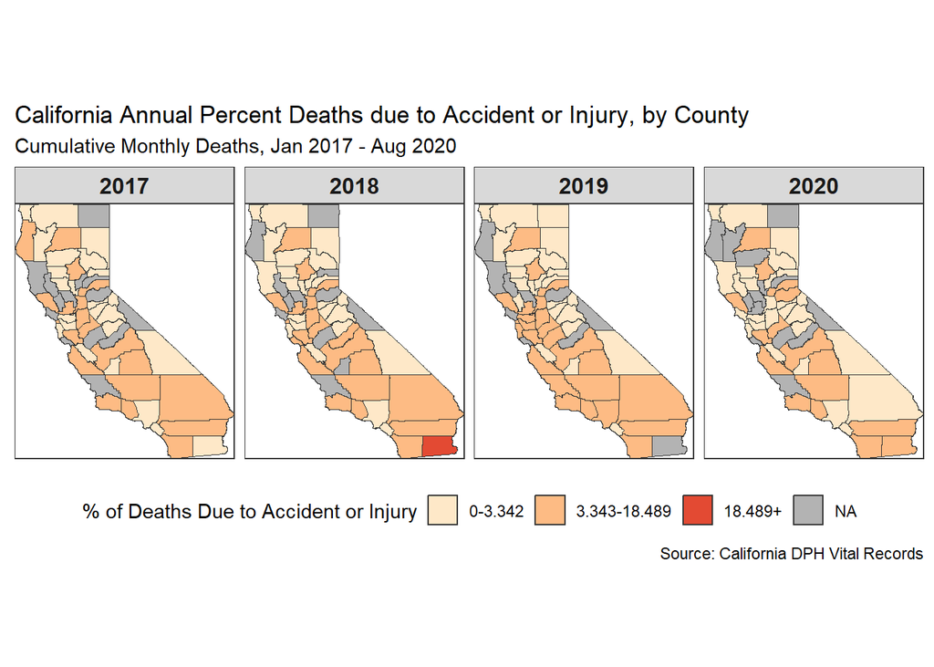

```r
## Notice that, with the minimum, 1st quartile, AND median all equal to 0, we
## really only have three groups

##### Now add on the cuts injuryDeathSummary labels for mapping:
injuryDeathSummary <- injuryDeathSummary %>%
  mutate(deathLabels = cut(deathsInjuriesPercent,
                          breaks = c(0, 3.343, 18.489, Inf),
                          labels = c("0-3.342", "3.343-18.489", "18.489+"),
                          ordered_result = TRUE, right = F))
```

#### Question 21A [0.5 points]::

Do you think there is any evidence that the percent of deaths due to accident & injury changed as a result of the stay-at-home orders? What would provide stronger evidence of a change in percent of deaths due to accident and injury as a result of the shutdown? Do these maps include any evidence of interaction with the sex of the decedent?

**Hint**: Make sure to explain what you would want to do to these maps, either in terms of filtering and/or additional faceting, to better address whether (1) the shutdown has had a likely effect and (2) whether there is an interaction with biological sex on the proportion of deaths due to accident or injury.

> MN: Based on these maps, I would say there is limited evidence that there is a change in trend due to stay ay home order. While on a county level there are some variations, statewide there is limited change. To address shuutdown, we could focus on monthly or quarterly data, and filter the maps by sex, and even possibly age, and type of death.

#### Question 21B [0.5 points]::

Why are some counties filled gray? Are the data truly missing or is it a data maturity problem? Or, is there another reason? (**Hint**: What will happen if the number of deaths in a county are very small?)

> MN: Some counties are filled in gray because there were too few deaths in that category for the data to be reported. This isnt always missing data, it can be an intentional suppression to protect individual privacy and avoid misleading statistics based on very small numbers. In small counties, only a few deaths could make someone identifiable, and going from a death rate of 1 to 3 in a small county can look like a VERY large increase.

#### Question 21C [3 points]::

Answer one of the two situations you answered in Question 21A. Either make more compelling maps before and after the shutdown OR show interactivity with biological sex, your choice.

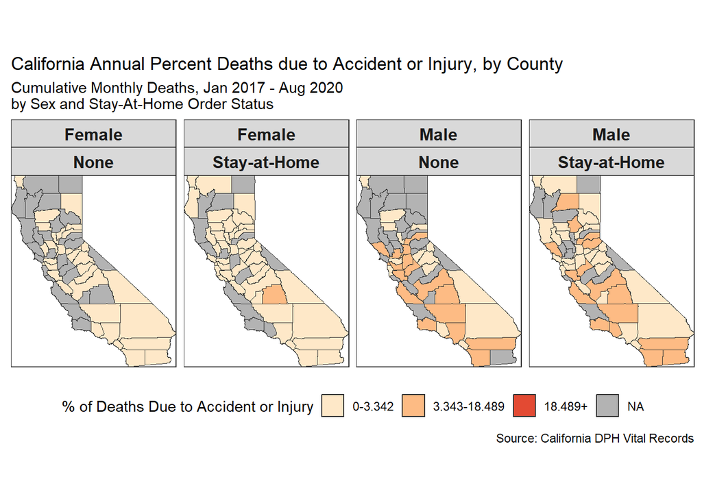

```r
## Initialize the plot
ggplot(injuryDeathSummary) +
  ## Chloropeth: draw the polygons of the counties and color by total deaths
  geom_sf(aes(fill = deathLabels), color = "gray20", size = 0.2) +

  ## Apply manual fill scale for total deaths
  scale_fill_manual(
    name = "% of Deaths Due to Accident or Injury",
    values = c4a(palette="brewer.or_rd", n=3),
    na.value = "gray70",
    drop = FALSE
  ) +
  ## Set map projection explicitly
  coord_sf(expand = FALSE) +   ## <- keeps map tight to its bounding box

  theme_bw() +
  ## Make a completely blank map background this time
  theme(
    panel.grid = element_blank(),
    panel.background = element_rect(fill = "white"),
    plot.background = element_rect(fill = "white"),
    axis.text = element_blank(),
    axis.ticks = element_blank(),
    axis.title = element_blank(),
    strip.text = element_text(size = 12, face = "bold"),
    legend.position = "bottom"
  ) +


  # Add title and caption
  labs(
    title = "California Annual Percent Deaths due to Accident or Injury, by County",
    subtitle = "Cumulative Monthly Deaths, Jan 2017 - Aug 2020 \nby Sex and Stay-At-Home Order Status",
    caption = "Source: California DPH Vital Records"
  ) +

  ## Use facet_wrap to make one map per year
  facet_wrap(~ biologicalSex + stayAtHome, ncol = 4)
```

### 5.1.3 Controlling for population-level differences in sex ratio

Even if you didn’t explore biological sex on the map, it seems that there are likely some sex-specific effects in percent of deaths due to accident and injury. But what if some counties have a **skewed sex ratio**? You might need to adjust for that! Although you might expect, *a priori*, for all counties to have a female to male ratio of 1:1, in reality that isn’t always the case.

In order to determine if you need to control for any underlying population-level differences in the sex ratio of each county, you make a simple histogram and plot a 1:1 line where the proportion of females in the population will equal males. You do this for each county. You make a **blue, solid line** for the mean sex-ratio, and a **black, dashed line** to show the reference 1:1 line.

**Note** that this ratio is coming from the Census data that you imported earlier; you calculated this sex ratio in an earlier code chunk from those data. Thus, these data are from 2020.

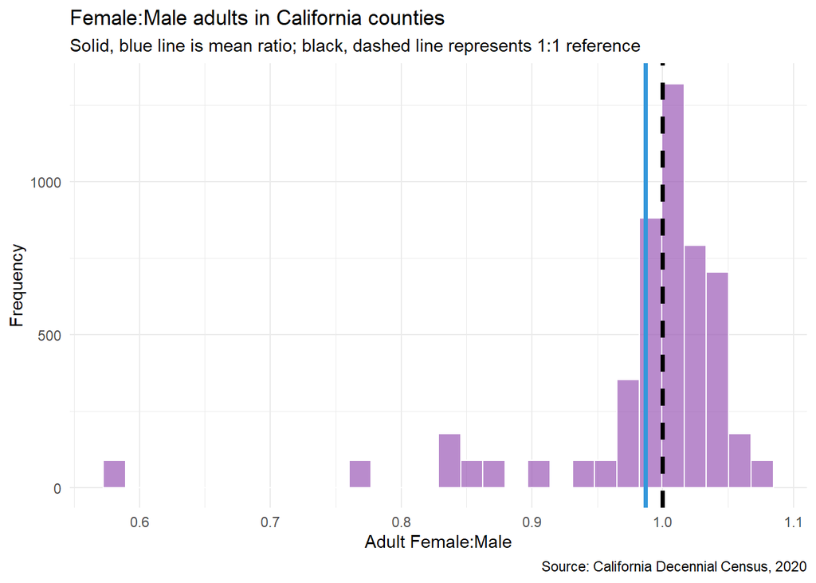

#### Question 22 [1 point]:

Calculate the correlation of `femaleMaleRatio` and the `deathsInjuriesProportion`, making sure to be careful to drop or exclude any NAs before making your calculation.

```r
#JML
test <- cor.test(injDeaths$femaleMaleRatio, injDeaths$deathsInjuriesProportion)
test
```

```
##
##  Pearson's product-moment correlation
##
## data:  injDeaths$femaleMaleRatio and injDeaths$deathsInjuriesProportion
## t = 12.596, df = 1868, p-value < 2.2e-16
## alternative hypothesis: true correlation is not equal to 0
## 95 percent confidence interval:
##  0.2374736 0.3210484
## sample estimates:
##      cor
## 0.279791
```

Do you think that this correlation coefficient indicates that you need to make a correction on your maps, or is it likely sufficient just to make the correction in your models? In other words, large correlation coefficients (in the absolute value sense) would indicate a need to correct the maps; smaller coefficients would indicate that it’s probably not a big deal for your visualizations provided to stakeholders.

> (JML) Based on the very small p-value, we’d reject the null hypothesis and conclude that there is a relationship between the two variables. However, because the correlation coefficient is approx 28%, we’d need to think about whether corrections should be made to the maps vs the models. The coefficient is less than 30%, which would be generally considered as small, but is getting close to being considered moderate. We have a large dataset of > 1800 records so there is a good amount of support for the idea that the evalutaion metrics are robust. I think that if we had unlimited time, we could modify the maps to account for this relationship, but in this case I’d probably leave the maps as they are as they wouldn’t affect the visualizations tremendously.

#### Question 23 [1 point]:

Now, take a look at the scatter plot below with a best-fit line. Does the plot agree with the correlation coefficient (i.e., direction of slope) you obtained? Why or why not?

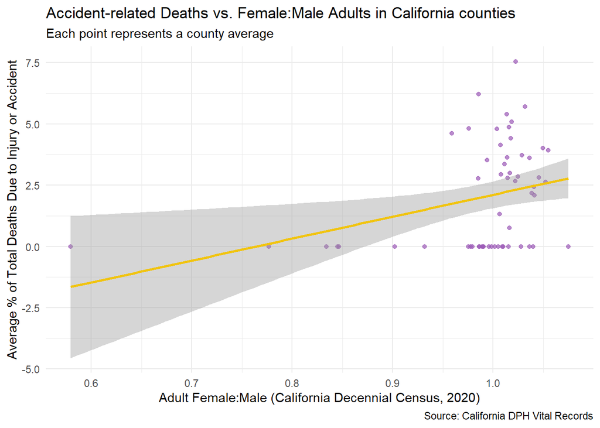

> (JML) Yes, the scatterplot’s gradual slope & direction from lower left to upper right is consistent with the correlation coefficient of .28.

#### Question 24 [3 points]:

Originally, I was going to walk you through predictive modeling here as well - but given a need to abbreviate this project, instead I am going to ask you to simply construct **data science question** and **hypothesis** given the information you have here so far. Are there any variables you pulled from the Census that would be worth considering here as well?

Choose what kind of model you would do. Would you include spatial lags? Ideally, would you include temporal lags?

> (JML) My data science question is “Did the California stay-at-home orders in spring 2020 have an effect on the rate of deaths at the county level due to accidents & injuries, and if so, what were the observed patterns of influence?” My hypothesis would be that the stay-at-home orders lowered the rate of deaths at the county level. I would use a random forest model, and I would include both spatial and temporal lags.

## 5.2 Choose your own cause-of-death to explore.

#### Question 25 [15 points]:

Now for the choose your own adventure portion of this assignment! Table 2 gives you a list of ICD-10 codes for the causes of death available in the dataset. You should be able to use the code in Section 5.1, with minimal adjustment, to explore your data.

Feel free to get creative! You are not required to continue stratifying by sex, unless you want to; in the Census data you pulled, you also have stratifications by **retirement age status** (over 65 years) or **double-stratified by both sex and retirement age**. You may also choose not to use any stratification if you wish.

##### For full credit, I will be looking for:

1. **Annual chloropeth maps showing your cause-of-death**, like this one
2. **A line graph showing changes, by month and year, in your cause-of-death**, somewhat like this one with stratification *optional*
3. **At least one other form of exploration to form a testable question or hypothesis, including but not limited to:**
- A correlation test
- A scatterplot
- Stratified boxplots
- Feel free to be creative!
4. **Interpretation** of all graphs or analyses explored.
5. **A data science question you would like to test**
6. **A data science hypothesis based on what you found** [Note: if you find nothing compelling, you may defend with evidence why there is no point developing a hypothesis instead.]

```r
## (JML)
## Join the sex deaths table with the census data; then filter for STK
stkDeaths <- sexDeaths %>%
  full_join(census, by = "County") %>%
  ## Here is where you filter for a specific cause of death relative to sex
  filter(leadingCauseDeath == "STK") %>%
  ## Now full join with the first 4 columns of the totalDeaths table to get
  ## total deaths also
  full_join(totalDeaths[ , 1:4], by = c("County", "Year", "Month")) %>%
  ## Rename the sexDeaths column to something more appropriate
  rename(strokeDeaths = sexDeaths) %>%
  ## Calculate the proportion of all deaths that are from injury
  ## RELATIVE TO ALL DEATHS (not population!!)
  mutate(deathsStkProportion = strokeDeaths/totalDeaths,
         ## The ratio of females to males in the population
         femaleMaleRatio = femalesN/malesN,
         ## The ratio of 65+ females to males in the population
         femaleMaleRatio65 = females65plus/males65plus,
         ## Ratio of retirees to non-retirees
         retireeRatio = over65/totalN,
         ## Convert the date to a date format for plotting
         Date = as.Date(paste(Year, Month, "1", sep = "-"),
                        format = "%Y-%m-%d")) %>%
         ## Illegal div by 0 turned to NaN; turn back to 0
  mutate(deathsStkProportion = ifelse(deathsStkProportion == "NaN",
                                           0, deathsStkProportion))

## Encode stayAtHome as any date after March 19, 2020
stkDeaths <- stkDeaths %>%
  mutate(stayAtHome = ifelse(Date >= "2020-03-19", "Stay-at-Home", "None"))


##### Calculate the proportion of all deaths due to suicide
stkDeathSummary <- stkDeaths %>%
  ## Group by stay-at-home order, year, county, AND sex
  group_by(stayAtHome, Year, County, biologicalSex) %>%
  ## Change the name to make the join easier
  rename(COUNTY_NAM = County) %>%
  ## Mean proportion of deaths for each month-year-county-sex combo
  summarise(deathsStkPercent = mean(deathsStkProportion, na.rm = TRUE)*100) %>%
  ## Join to get the geometries for mapping
  full_join(cali_sf, by = "COUNTY_NAM", relationship = "many-to-many") %>%
  ## Coerce to make sure it is seen as a shapefile
  st_as_sf() %>%
  ## Remove any of the island geometries as you did in the first part
  filter(is.na(ISLAND)) %>%
  ungroup()

#### Find the five number summary
summ <- fivenum(stkDeathSummary$deathsStkPercent)
paste0("The five-number summary of % of deaths that are stroke-related is: ")
```

```
## [1] "The five-number summary of % of deaths that are stroke-related is: "
```

```r
paste(c("Min", "Lower Quartile", "Median", "Upper Quartile", "Max"),
      round(summ, 3))
```

```
## [1] "Min 0"                "Lower Quartile 0"     "Median 0"
## [4] "Upper Quartile 3.301" "Max 11.739"
```

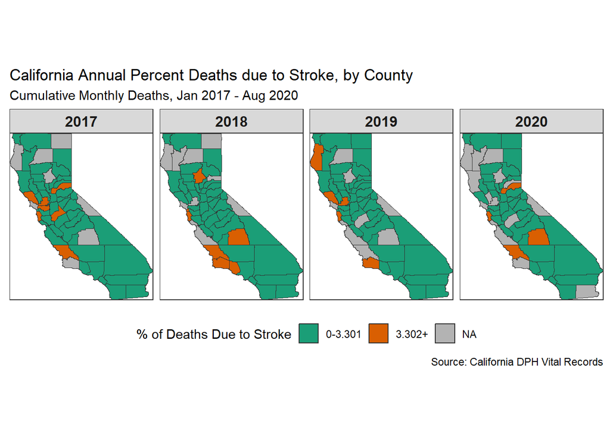

```r
##### Now add on the cuts stkDeathSummary labels for mapping:
stkDeathSummary <- stkDeathSummary %>%
  mutate(stkDeathLabels = cut(deathsStkPercent,
                          breaks = c(0, 3.302, Inf),
                          labels = c("0-3.301", "3.302+"),
                          ordered_result = TRUE, right = F))

## Initialize the Chloropeth plot
ggplot(stkDeathSummary) +
  ## Chloropeth: draw the polygons of the counties and color by total deaths
  geom_sf(aes(fill = stkDeathLabels), color = "gray20", size = 0.2) +

  ## Apply manual fill scale for total deaths
  scale_fill_manual(
    name = "% of Deaths Due to Stroke",
    values = c4a(palette="brewer.dark2", n=3),
    na.value = "gray70",
    drop = FALSE
  ) +
  ## Set map projection explicitly
  coord_sf(expand = FALSE) +   ## <- keeps map tight to its bounding box

  theme_bw() +
  ## Make a completely blank map background this time
  theme(
    panel.grid = element_blank(),
    panel.background = element_rect(fill = "white"),
    plot.background = element_rect(fill = "white"),
    axis.text = element_blank(),
    axis.ticks = element_blank(),
    axis.title = element_blank(),
    strip.text = element_text(size = 12, face = "bold"),
    legend.position = "bottom"
  ) +
  # Add title and caption
  labs(
    title = "California Annual Percent Deaths due to Stroke, by County",
    subtitle = "Cumulative Monthly Deaths, Jan 2017 - Aug 2020",
    caption = "Source: California DPH Vital Records"
  ) +
  ## Use facet_wrap to make one map per year
  facet_wrap(~ Year, ncol = 4)
```

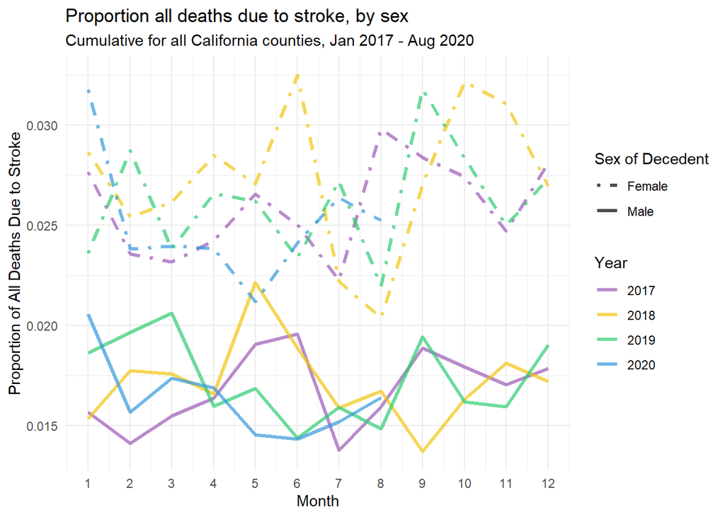

```r
## Proportion all deaths due to stroke, by sex
stkDeaths %>%
  group_by(Month, biologicalSex, Year) %>%
  summarise(deathsStkProportion = mean(deathsStkProportion, na.rm = TRUE)) %>%
ggplot(aes(x = Month,
           y = deathsStkProportion,
           color = as.factor(Year),
           linetype = as.factor(biologicalSex))) +
  geom_line(alpha = 0.7, size = 1.1) +
  scale_x_continuous(n.breaks = 10) +
  scale_color_manual(values = skittles[c(5, 2:4)]) +
  scale_linetype_manual(values=c("dotdash", "solid")) +
  labs(title = "Proportion all deaths due to stroke, by sex",
       y = "Proportion of All Deaths Due to Stroke",
       subtitle = "Cumulative for all California counties, Jan 2017 - Aug 2020",
       color = "Year",
       linetype = "Sex of Decedent") +
  theme_minimal()
```

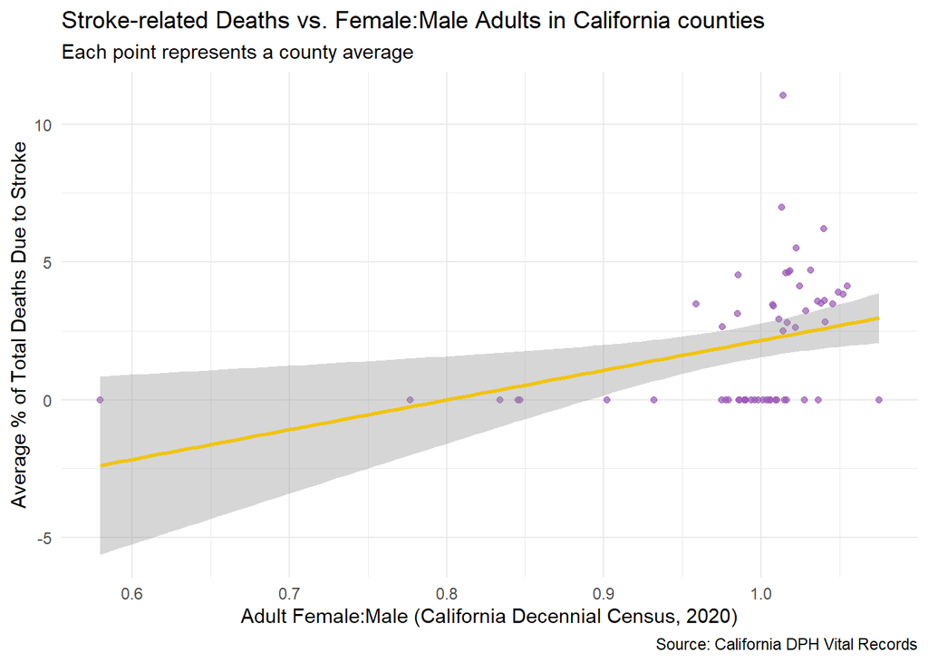

```r
## scatterplot
stkDeaths %>%
  group_by(County) %>%
  summarise(femaleMaleRatio = mean(femaleMaleRatio),
            deathsStkPercent = mean(deathsStkProportion,
                                         na.rm = TRUE)*100) %>%

  ggplot(aes(x = femaleMaleRatio, y = deathsStkPercent)) +
  geom_point(alpha = 0.7, color = skittles[5]) +
  geom_smooth(color = skittles[2], method = "lm") +
  labs(title = "Stroke-related Deaths vs. Female:Male Adults in California counties",
       subtitle = "Each point represents a county average",
       y = "Average % of Total Deaths Due to Stroke",
       x = "Adult Female:Male (California Decennial Census, 2020)",
       caption = "Source: California DPH Vital Records") +
  theme_minimal()
```

```r
## correlation test
strkeTest <- cor.test(stkDeaths$femaleMaleRatio, stkDeaths$deathsStkProportion)
strkeTest
```

```
##
##  Pearson's product-moment correlation
##
## data:  stkDeaths$femaleMaleRatio and stkDeaths$deathsStkProportion
## t = 23.286, df = 2356, p-value < 2.2e-16
## alternative hypothesis: true correlation is not equal to 0
## 95 percent confidence interval:
##  0.3991378 0.4647861
## sample estimates:
##      cor
## 0.432535
```

##### Interpretations of visualizations

Interpretation of chloropeth map

> (JML) Looking at the chloropeth maps for each of the 4 years, there doesn’t appear to be much change in the rates of death due to stroke. However, having only two rate classifications does make it challenging to find meaningful differences.

Interpretation of proportion of all deaths due to stroke by sex

> (JML) According to this plot, females represent a higher proportion of deaths due to stroke than males. That trend occurs in each of the four years being presented. None of the years appears to have much higher or lower rates of stroke deaths than other years.

Interpretation of scatterplot

> (JML) The scatterplot’s gradual slope and direction from lower left to upper right is consistent with the correlation coefficient of .43.

Interpretation of correlation test

> (JML) Based on the very small p-value, we’d reject the null hypothesis and conclude that there is a relationship between the two variables. Additionally, because the correlation coefficient is approx 43%, we should need to strongly consider making corrections to the maps. We have a large dataset of > 2300 records so there is a good amount of support for the idea that the evalutaion metrics are meaningful.

Data science question to be tested

> (JML) Did the California stay-at-home orders in spring 2020 have an effect on the rate of deaths at the county level due to stroke, and if so, what were the observed patterns of influence?

Data science hypothesis

> (JML) The hypothesis would be that the stay-at-home orders had no effect on the rate of deaths due to stroke at the county level. I believe that this hypothesis is supported by the visualizations developed.